# Supermarket sales analysis-project

```python
import os
import pandas as pd
import numpy as np
import matplotlib as mpl
import matplotlib.pyplot as plt
import seaborn as sns
import re
sns.set()

%matplotlib inline
sns.set()


plt.tight_layout()  # to fit the tixt overlap in the graph --
```

```python
pd.set_option('display.max_columns', 1000) # to see all columns data
pd.set_option('display.max_rows', 300) # to see all columns data
#pd.set_option('display.float_format', '{:.2%}'.format)
#pd.options.display.float_format = None
pd.set_option("display.max_colwidth", -1) # display the full text
```

## Read the Data and Exploring it (EDA) ------

```python
df= pd.read_excel("buying_data.xlsx")

df_QVI_behaviour= pd.read_csv("buying_behaviour.csv")
```

```python
df.info()
```

```
<class 'pandas.core.frame.DataFrame'>
RangeIndex: 264836 entries, 0 to 264835
Data columns (total 8 columns):
 #   Column          Non-Null Count   Dtype
---  ------          --------------   -----
 0   DATE            264836 non-null  datetime64[ns]
 1   STORE_NBR       264836 non-null  int64
 2   LYLTY_CARD_NBR  264836 non-null  int64
 3   TXN_ID          264836 non-null  int64
 4   PROD_NBR        264836 non-null  int64
 5   PROD_NAME       264836 non-null  object
 6   PROD_QTY        264836 non-null  int64
 7   TOT_SALES       264836 non-null  float64
dtypes: datetime64[ns](1), float64(1), int64(5), object(1)
memory usage: 16.2+ MB
```

```python
df.head (10)
```

|  | DATE | STORE_NBR | LYLTY_CARD_NBR | TXN_ID | PROD_NBR | PROD_NAME | PROD_QTY | TOT_SALES |
| --- | --- | --- | --- | --- | --- | --- | --- | --- |
| 0 | 2018-07-01 | 47 | 47142 | 42540 | 14 | Smiths Crnkle Chip Orgnl Big Bag 380g | 2 | 11.8 |
| 1 | 2018-07-01 | 55 | 55073 | 48884 | 99 | Pringles Sthrn FriedChicken 134g | 2 | 7.4 |
| 2 | 2018-07-01 | 55 | 55073 | 48884 | 91 | CCs Tasty Cheese 175g | 2 | 4.2 |
| 3 | 2018-07-01 | 58 | 58351 | 54374 | 102 | Kettle Mozzarella Basil & Pesto 175g | 2 | 10.8 |
| 4 | 2018-07-01 | 68 | 68193 | 65598 | 44 | Thins Chips Light& Tangy 175g | 2 | 6.6 |
| 5 | 2018-07-01 | 69 | 69207 | 67156 | 49 | Infuzions SourCream&Herbs Veg Strws 110g | 2 | 7.6 |
| 6 | 2018-07-01 | 78 | 78009 | 75510 | 35 | Woolworths Mild Salsa 300g | 2 | 3.0 |
| 7 | 2018-07-01 | 104 | 104017 | 103795 | 84 | GrnWves Plus Btroot & Chilli Jam 180g | 2 | 6.2 |
| 8 | 2018-07-01 | 113 | 113032 | 115576 | 6 | RRD Lime & Pepper 165g | 2 | 6.0 |
| 9 | 2018-07-01 | 119 | 119051 | 122360 | 113 | Twisties Chicken270g | 2 | 9.2 |

```python
df.tail()
```

|  | DATE | STORE_NBR | LYLTY_CARD_NBR | TXN_ID | PROD_NBR | PROD_NAME | PROD_QTY | TOT_SALES |
| --- | --- | --- | --- | --- | --- | --- | --- | --- |
| 264831 | 2019-06-30 | 242 | 242159 | 246222 | 36 | Kettle Chilli 175g | 2 | 10.8 |
| 264832 | 2019-06-30 | 244 | 244213 | 247339 | 93 | Doritos Corn Chip Southern Chicken 150g | 2 | 7.8 |
| 264833 | 2019-06-30 | 256 | 256018 | 255130 | 105 | Woolworths Cheese Rings 190g | 2 | 3.6 |
| 264834 | 2019-06-30 | 257 | 257079 | 256218 | 71 | Twisties Cheese Burger 250g | 2 | 8.6 |
| 264835 | 2019-06-30 | 265 | 265006 | 263307 | 106 | Natural ChipCo Hony Soy Chckn175g | 1 | 3.0 |

```python
df.describe().round(2)
```

|  | DATE | STORE_NBR | LYLTY_CARD_NBR | TXN_ID | PROD_NBR | PROD_QTY | TOT_SALES |
| --- | --- | --- | --- | --- | --- | --- | --- |
| count | 264836 | 264836.00 | 264836.00 | 264836.00 | 264836.00 | 264836.00 | 264836.00 |
| mean | 2018-12-30 00:52:12.879215616 | 135.08 | 135549.48 | 135158.31 | 56.58 | 1.91 | 7.30 |
| min | 2018-07-01 00:00:00 | 1.00 | 1000.00 | 1.00 | 1.00 | 1.00 | 1.50 |
| 25% | 2018-09-30 00:00:00 | 70.00 | 70021.00 | 67601.50 | 28.00 | 2.00 | 5.40 |
| 50% | 2018-12-30 00:00:00 | 130.00 | 130357.50 | 135137.50 | 56.00 | 2.00 | 7.40 |
| 75% | 2019-03-31 00:00:00 | 203.00 | 203094.25 | 202701.25 | 85.00 | 2.00 | 9.20 |
| max | 2019-06-30 00:00:00 | 272.00 | 2373711.00 | 2415841.00 | 114.00 | 200.00 | 650.00 |
| std | NaN | 76.78 | 80579.98 | 78133.03 | 32.83 | 0.64 | 3.08 |

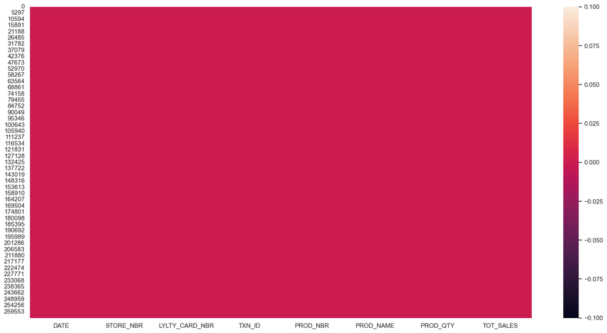

```python
# check the nan Values with visualizing it

plt.figure(figsize=(20,10))
sns.heatmap(df.isna())
```

```
array([<AxesSubplot:>, <AxesSubplot:>, <AxesSubplot:>, <AxesSubplot:>,
       <AxesSubplot:>, <AxesSubplot:>, <AxesSubplot:>], dtype=object)
```

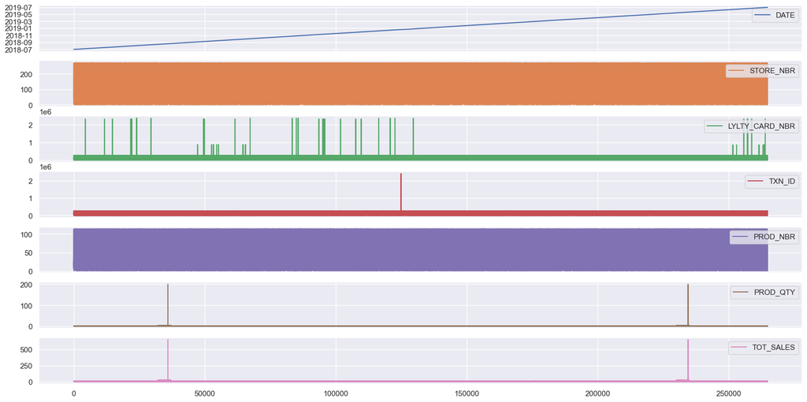

```python
# check the outlier values for the numerical data by visualizing-----

df.plot(subplots= True, figsize=(20,10))
```

```python
df
```

|  | DATE | STORE_NBR | LYLTY_CARD_NBR | TXN_ID | PROD_NBR | PROD_NAME | PROD_QTY | TOT_SALES |
| --- | --- | --- | --- | --- | --- | --- | --- | --- |
| 0 | 2018-07-01 | 47 | 47142 | 42540 | 14 | Smiths Crnkle Chip Orgnl Big Bag 380g | 2 | 11.8 |
| 1 | 2018-07-01 | 55 | 55073 | 48884 | 99 | Pringles Sthrn FriedChicken 134g | 2 | 7.4 |
| 2 | 2018-07-01 | 55 | 55073 | 48884 | 91 | CCs Tasty Cheese 175g | 2 | 4.2 |
| 3 | 2018-07-01 | 58 | 58351 | 54374 | 102 | Kettle Mozzarella Basil & Pesto 175g | 2 | 10.8 |
| 4 | 2018-07-01 | 68 | 68193 | 65598 | 44 | Thins Chips Light& Tangy 175g | 2 | 6.6 |
| ... | ... | ... | ... | ... | ... | ... | ... | ... |
| 264831 | 2019-06-30 | 242 | 242159 | 246222 | 36 | Kettle Chilli 175g | 2 | 10.8 |
| 264832 | 2019-06-30 | 244 | 244213 | 247339 | 93 | Doritos Corn Chip Southern Chicken 150g | 2 | 7.8 |
| 264833 | 2019-06-30 | 256 | 256018 | 255130 | 105 | Woolworths Cheese Rings 190g | 2 | 3.6 |
| 264834 | 2019-06-30 | 257 | 257079 | 256218 | 71 | Twisties Cheese Burger 250g | 2 | 8.6 |
| 264835 | 2019-06-30 | 265 | 265006 | 263307 | 106 | Natural ChipCo Hony Soy Chckn175g | 1 | 3.0 |

264836 rows × 8 columns

```python
# check random values ------
#df.sample(1).iloc[0]

df.sample(10)
```

|  | DATE | STORE_NBR | LYLTY_CARD_NBR | TXN_ID | PROD_NBR | PROD_NAME | PROD_QTY | TOT_SALES |
| --- | --- | --- | --- | --- | --- | --- | --- | --- |
| 140614 | 2019-01-10 | 57 | 57185 | 52333 | 90 | Tostitos Smoked Chipotle 175g | 2 | 8.8 |
| 191161 | 2019-03-21 | 235 | 235119 | 238048 | 68 | Pringles Chicken Salt Crips 134g | 2 | 7.4 |
| 208479 | 2019-04-14 | 250 | 250005 | 251484 | 28 | Thins Potato Chips Hot & Spicy 175g | 2 | 6.6 |
| 245841 | 2019-06-05 | 109 | 109101 | 110810 | 32 | Kettle Sea Salt And Vinegar 175g | 2 | 10.8 |
| 59583 | 2018-09-21 | 213 | 213166 | 212983 | 54 | CCs Original 175g | 2 | 4.2 |
| 151675 | 2019-01-26 | 39 | 39085 | 35143 | 47 | Doritos Corn Chips Original 170g | 2 | 8.8 |
| 217610 | 2019-04-26 | 197 | 197427 | 197413 | 114 | Kettle Sensations Siracha Lime 150g | 2 | 9.2 |
| 62241 | 2018-09-24 | 154 | 154124 | 153972 | 77 | Doritos Corn Chips Nacho Cheese 170g | 1 | 4.4 |
| 14877 | 2018-07-21 | 130 | 130073 | 133959 | 7 | Smiths Crinkle Original 330g | 2 | 11.4 |
| 199560 | 2019-04-02 | 109 | 109150 | 111077 | 61 | Smiths Crinkle Cut Chips Chicken 170g | 2 | 5.8 |

```python
# check the numbers of unique values in each column---------

df.nunique()
```

```
DATE              364
STORE_NBR         272
LYLTY_CARD_NBR    72637
TXN_ID            263127
PROD_NBR          114
PROD_NAME         114
PROD_QTY          6
TOT_SALES         112
dtype: int64
```

```python
# Check All unique products names -----------
df["PROD_NAME"].drop_duplicates()
```

```
0       Smiths Crnkle Chip  Orgnl Big Bag 380g
1       Pringles Sthrn FriedChicken 134g
2       CCs Tasty Cheese    175g
3       Kettle Mozzarella   Basil & Pesto 175g
4       Thins Chips Light&  Tangy 175g
5       Infuzions SourCream&Herbs Veg Strws 110g
6       Woolworths Mild     Salsa 300g
7       GrnWves Plus Btroot & Chilli Jam 180g
8       RRD Lime & Pepper   165g
9       Twisties Chicken270g
10      Red Rock Deli Thai  Chilli&Lime 150g
11      Old El Paso Salsa   Dip Tomato Med 300g
12      Smiths Crinkle Cut  French OnionDip 150g
13      Twisties Cheese     270g
15      Smiths Crinkle      Original 330g
```

[output cut: 100 more lines]

```python
# Check uniques values in the two columns or more ---------------

df[['PROD_QTY',"PROD_NAME"]].drop_duplicates().sample(15)
```

|  | PROD_QTY | PROD_NAME |
| --- | --- | --- |
| 32343 | 3 | GrnWves Plus Btroot & Chilli Jam 180g |
| 36971 | 4 | Infzns Crn Crnchers Tangy Gcamole 110g |
| 1193 | 1 | WW Sour Cream &OnionStacked Chips 160g |
| 483 | 1 | Kettle Mozzarella Basil & Pesto 175g |
| 464 | 1 | Doritos Corn Chip Southern Chicken 150g |
| 230326 | 5 | Woolworths Cheese Rings 190g |
| 985 | 1 | Kettle Original 175g |
| 34615 | 5 | Dorito Corn Chp Supreme 380g |
| 32220 | 3 | Kettle Sensations BBQ&Maple 150g |
| 231216 | 5 | Infuzions Mango Chutny Papadums 70g |
| 35586 | 5 | WW Supreme Cheese Corn Chips 200g |
| 35399 | 3 | Kettle Honey Soy Chicken 175g |
| 209 | 2 | Smiths Chip Thinly S/Cream&Onion 175g |
| 1291 | 1 | Old El Paso Salsa Dip Tomato Med 300g |
| 98 | 2 | Cheetos Puffs 165g |

```python
df.sample(15)
```

|  | DATE | STORE_NBR | LYLTY_CARD_NBR | TXN_ID | PROD_NBR | PROD_NAME | PROD_QTY | TOT_SALES |
| --- | --- | --- | --- | --- | --- | --- | --- | --- |
| 229862 | 2019-05-13 | 81 | 81300 | 81072 | 104 | Infuzions Thai SweetChili PotatoMix 110g | 2 | 7.6 |
| 230588 | 2019-05-14 | 72 | 72184 | 71423 | 25 | Pringles SourCream Onion 134g | 1 | 3.7 |
| 37044 | 2018-08-20 | 50 | 50203 | 46348 | 22 | Thins Chips Originl saltd 175g | 1 | 3.3 |
| 1497 | 2018-07-03 | 223 | 223111 | 223578 | 74 | Tostitos Splash Of Lime 175g | 2 | 8.8 |
| 191857 | 2019-03-22 | 250 | 250319 | 252773 | 71 | Twisties Cheese Burger 250g | 2 | 8.6 |
| 116628 | 2018-12-09 | 94 | 94015 | 92531 | 73 | Smiths Crinkle Cut Salt & Vinegar 170g | 2 | 5.8 |
| 208435 | 2019-04-14 | 80 | 80147 | 78853 | 47 | Doritos Corn Chips Original 170g | 2 | 8.8 |
| 187118 | 2019-03-15 | 150 | 150368 | 149718 | 31 | Infzns Crn Crnchers Tangy Gcamole 110g | 2 | 7.6 |
| 109483 | 2018-11-29 | 71 | 71029 | 69082 | 102 | Kettle Mozzarella Basil & Pesto 175g | 2 | 10.8 |
| 129137 | 2018-12-24 | 153 | 153316 | 153227 | 99 | Pringles Sthrn FriedChicken 134g | 2 | 7.4 |
| 17351 | 2018-07-24 | 69 | 69166 | 66913 | 1 | Smiths Crinkle Cut Chips Barbecue 170g | 2 | 5.8 |
| 103315 | 2018-11-20 | 49 | 49325 | 45865 | 114 | Kettle Sensations Siracha Lime 150g | 2 | 9.2 |
| 105438 | 2018-11-23 | 75 | 75122 | 73881 | 2 | Cobs Popd Sour Crm &Chives Chips 110g | 2 | 7.6 |
| 212229 | 2019-04-19 | 28 | 28216 | 25807 | 111 | Smiths Chip Thinly Cut Original 175g | 2 | 6.0 |
| 111273 | 2018-12-01 | 62 | 62222 | 59094 | 19 | Smiths Crinkle Cut Snag&Sauce 150g | 2 | 5.2 |

## Some notes:

1- The PROD_NAME column has some problems such as different spaces between words.

2- Some times in the same column g or G

3- Data from 2018-07-01 to 2019-06-30

### 1- Replace the multiples whitespace to one with space

```python
# Replace the multiples whitespace to one with space --------


df["PROD_NAME"]=df["PROD_NAME"].str.replace(r"\ +", " ")
```

```python
df["PROD_NAME"].drop_duplicates()
```

```
0       Smiths Crnkle Chip Orgnl Big Bag 380g
1       Pringles Sthrn FriedChicken 134g
2       CCs Tasty Cheese 175g
3       Kettle Mozzarella Basil & Pesto 175g
4       Thins Chips Light& Tangy 175g
5       Infuzions SourCream&Herbs Veg Strws 110g
6       Woolworths Mild Salsa 300g
7       GrnWves Plus Btroot & Chilli Jam 180g
8       RRD Lime & Pepper 165g
9       Twisties Chicken270g
10      Red Rock Deli Thai Chilli&Lime 150g
11      Old El Paso Salsa Dip Tomato Med 300g
12      Smiths Crinkle Cut French OnionDip 150g
13      Twisties Cheese 270g
15      Smiths Crinkle Original 330g
```

[output cut: 100 more lines]

```python
# Create new separate column called "Weight" ---

df["Weight"]= df["PROD_NAME"].str.split(" ").str.get(-1)
```

```python
df
```

|  | DATE | STORE_NBR | LYLTY_CARD_NBR | TXN_ID | PROD_NBR | PROD_NAME | PROD_QTY | TOT_SALES | Weight |
| --- | --- | --- | --- | --- | --- | --- | --- | --- | --- |
| 0 | 2018-07-01 | 47 | 47142 | 42540 | 14 | Smiths Crnkle Chip Orgnl Big Bag 380g | 2 | 11.8 | 380g |
| 1 | 2018-07-01 | 55 | 55073 | 48884 | 99 | Pringles Sthrn FriedChicken 134g | 2 | 7.4 | 134g |
| 2 | 2018-07-01 | 55 | 55073 | 48884 | 91 | CCs Tasty Cheese 175g | 2 | 4.2 | 175g |
| 3 | 2018-07-01 | 58 | 58351 | 54374 | 102 | Kettle Mozzarella Basil & Pesto 175g | 2 | 10.8 | 175g |
| 4 | 2018-07-01 | 68 | 68193 | 65598 | 44 | Thins Chips Light& Tangy 175g | 2 | 6.6 | 175g |
| ... | ... | ... | ... | ... | ... | ... | ... | ... | ... |
| 264831 | 2019-06-30 | 242 | 242159 | 246222 | 36 | Kettle Chilli 175g | 2 | 10.8 | 175g |
| 264832 | 2019-06-30 | 244 | 244213 | 247339 | 93 | Doritos Corn Chip Southern Chicken 150g | 2 | 7.8 | 150g |
| 264833 | 2019-06-30 | 256 | 256018 | 255130 | 105 | Woolworths Cheese Rings 190g | 2 | 3.6 | 190g |
| 264834 | 2019-06-30 | 257 | 257079 | 256218 | 71 | Twisties Cheese Burger 250g | 2 | 8.6 | 250g |
| 264835 | 2019-06-30 | 265 | 265006 | 263307 | 106 | Natural ChipCo Hony Soy Chckn175g | 1 | 3.0 | Chckn175g |

264836 rows × 9 columns

```python
# Check the product name to find where and why the weight empty values with which product -------
# I found that  " Kettle 135g Swt Pot Sea Salt"
# I found 30 unique values in Weight cloumn ????? why -----

df["Weight"].nunique()  # --- 30 unique values

df["Weight"].drop_duplicates()
```

```
0       380g
1       134g
2       175g
5       110g
6       300g
7       180g
8       165g
9       Chicken270g
10      150g
13      270g
15      330g
19      170g
31      160g
37      Chs&Onion170g
39      210G
```

[output cut: 16 more lines]

```python
# For solve the problem, I should add the regex between pair of parenthesis like that (r"(\d+[g|G])") not like that (r"[\d+[g|G]")

# Separate text from weight column in new column called Net_Weight ----

df["Net_Weight"]= df["Weight"].str.extract(r"(\d+[g|G])")
```

```python
df
```

|  | DATE | STORE_NBR | LYLTY_CARD_NBR | TXN_ID | PROD_NBR | PROD_NAME | PROD_QTY | TOT_SALES | Weight | Net_Weight |
| --- | --- | --- | --- | --- | --- | --- | --- | --- | --- | --- |
| 0 | 2018-07-01 | 47 | 47142 | 42540 | 14 | Smiths Crnkle Chip Orgnl Big Bag 380g | 2 | 11.8 | 380g | 380g |
| 1 | 2018-07-01 | 55 | 55073 | 48884 | 99 | Pringles Sthrn FriedChicken 134g | 2 | 7.4 | 134g | 134g |
| 2 | 2018-07-01 | 55 | 55073 | 48884 | 91 | CCs Tasty Cheese 175g | 2 | 4.2 | 175g | 175g |
| 3 | 2018-07-01 | 58 | 58351 | 54374 | 102 | Kettle Mozzarella Basil & Pesto 175g | 2 | 10.8 | 175g | 175g |
| 4 | 2018-07-01 | 68 | 68193 | 65598 | 44 | Thins Chips Light& Tangy 175g | 2 | 6.6 | 175g | 175g |
| ... | ... | ... | ... | ... | ... | ... | ... | ... | ... | ... |
| 264831 | 2019-06-30 | 242 | 242159 | 246222 | 36 | Kettle Chilli 175g | 2 | 10.8 | 175g | 175g |
| 264832 | 2019-06-30 | 244 | 244213 | 247339 | 93 | Doritos Corn Chip Southern Chicken 150g | 2 | 7.8 | 150g | 150g |
| 264833 | 2019-06-30 | 256 | 256018 | 255130 | 105 | Woolworths Cheese Rings 190g | 2 | 3.6 | 190g | 190g |
| 264834 | 2019-06-30 | 257 | 257079 | 256218 | 71 | Twisties Cheese Burger 250g | 2 | 8.6 | 250g | 250g |
| 264835 | 2019-06-30 | 265 | 265006 | 263307 | 106 | Natural ChipCo Hony Soy Chckn175g | 1 | 3.0 | Chckn175g | 175g |

264836 rows × 10 columns

```python
df["Net_Weight"].sample(50)
```

```
114066    175g
7463      165g
13832     330g
165514    380g
243467    150g
76361     175g
257350    175g
217473    175g
202094    175g
251880    220g
185871    134g
79594     170g
8880      270g
28441     150g
244190    150g
```

[output cut: 186 more lines]

```python
# Check the product name to find where and why the Net_Weight empty values with which product -------
# I found that  " Kettle 135g Swt Pot Sea Salt"
# I found 30 unique values in Weight cloumn ????? why -----

df["Net_Weight"].nunique()
```

```
23
```

```python
df["Net_Weight"].drop_duplicates()
```

```
0      380g
1      134g
2      175g
5      110g
6      300g
7      180g
8      165g
9      270g
10     150g
15     330g
19     170g
31     160g
39     210G
58     125g
63     220g
70     NaN
76     200g
78     210g
111    175G
190    250g
198    150G
211    90g
480    190g
621    70g
Name: Net_Weight, dtype: object
```

```python
df.info()
```

```
<class 'pandas.core.frame.DataFrame'>
RangeIndex: 264836 entries, 0 to 264835
Data columns (total 10 columns):
 #   Column          Non-Null Count   Dtype
---  ------          --------------   -----
 0   DATE            264836 non-null  datetime64[ns]
 1   STORE_NBR       264836 non-null  int64
 2   LYLTY_CARD_NBR  264836 non-null  int64
 3   TXN_ID          264836 non-null  int64
 4   PROD_NBR        264836 non-null  int64
 5   PROD_NAME       264836 non-null  object
 6   PROD_QTY        264836 non-null  int64
 7   TOT_SALES       264836 non-null  float64
 8   Weight          264836 non-null  object
 9   Net_Weight      261579 non-null  object
dtypes: datetime64[ns](1), float64(1), int64(5), object(3)
memory usage: 20.2+ MB
```

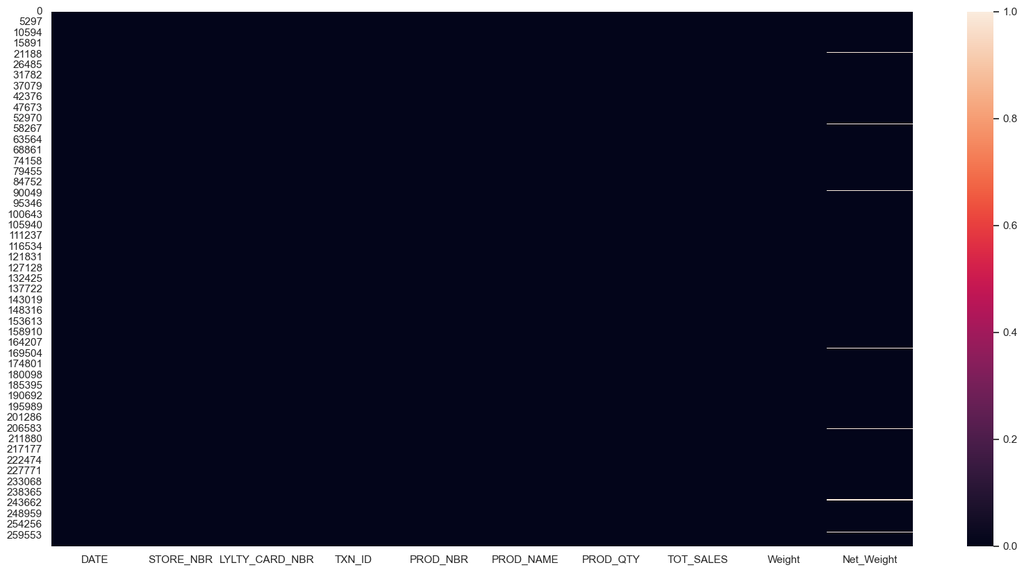

```python
# check the nan Values with visualizing it

plt.figure(figsize=(20,10))
sns.heatmap(df.isna())
```

```python
# Check NaN Values in Net_Weight column ----
# The nan values because when I seprate the weight from product name column the weight of Kettle 135g Swt Pot Sea Salt is in between so the value will be "Salt", so when I try to seprate the text in second step to Net_weight column vlau converted to Nan to I will replace Nan Valure to 135g

df.iloc[49107]
```

```
DATE              2018-09-06 00:00:00
STORE_NBR         233
LYLTY_CARD_NBR    233362
TXN_ID            237139
PROD_NBR          63
PROD_NAME         Kettle 135g Swt Pot Sea Salt
PROD_QTY          2
TOT_SALES         8.4
Weight            Salt
Net_Weight        NaN
Name: 49107, dtype: object
```

```python
df.fillna({"Net_Weight":"135g"}, inplace=True)
```

```python
df.iloc[49107]
```

```
DATE              2018-09-06 00:00:00
STORE_NBR         233
LYLTY_CARD_NBR    233362
TXN_ID            237139
PROD_NBR          63
PROD_NAME         Kettle 135g Swt Pot Sea Salt
PROD_QTY          2
TOT_SALES         8.4
Weight            Salt
Net_Weight        135g
Name: 49107, dtype: object
```

```python
df["Net_Weight"].drop_duplicates()
```

```
0      380g
1      134g
2      175g
5      110g
6      300g
7      180g
8      165g
9      270g
10     150g
15     330g
19     170g
31     160g
39     210G
58     125g
63     220g
70     135g
76     200g
78     210g
111    175G
190    250g
198    150G
211    90g
480    190g
621    70g
Name: Net_Weight, dtype: object
```

```python
df["PROD_NAME"].drop_duplicates()
```

```
0       Smiths Crnkle Chip Orgnl Big Bag 380g
1       Pringles Sthrn FriedChicken 134g
2       CCs Tasty Cheese 175g
3       Kettle Mozzarella Basil & Pesto 175g
4       Thins Chips Light& Tangy 175g
5       Infuzions SourCream&Herbs Veg Strws 110g
6       Woolworths Mild Salsa 300g
7       GrnWves Plus Btroot & Chilli Jam 180g
8       RRD Lime & Pepper 165g
9       Twisties Chicken270g
10      Red Rock Deli Thai Chilli&Lime 150g
11      Old El Paso Salsa Dip Tomato Med 300g
12      Smiths Crinkle Cut French OnionDip 150g
13      Twisties Cheese 270g
15      Smiths Crinkle Original 330g
```

[output cut: 100 more lines]

```python
df.drop("Weight", axis=1, inplace=True)
```

```python
df
```

|  | DATE | STORE_NBR | LYLTY_CARD_NBR | TXN_ID | PROD_NBR | PROD_NAME | PROD_QTY | TOT_SALES | Net_Weight |
| --- | --- | --- | --- | --- | --- | --- | --- | --- | --- |
| 0 | 2018-07-01 | 47 | 47142 | 42540 | 14 | Smiths Crnkle Chip Orgnl Big Bag 380g | 2 | 11.8 | 380g |
| 1 | 2018-07-01 | 55 | 55073 | 48884 | 99 | Pringles Sthrn FriedChicken 134g | 2 | 7.4 | 134g |
| 2 | 2018-07-01 | 55 | 55073 | 48884 | 91 | CCs Tasty Cheese 175g | 2 | 4.2 | 175g |
| 3 | 2018-07-01 | 58 | 58351 | 54374 | 102 | Kettle Mozzarella Basil & Pesto 175g | 2 | 10.8 | 175g |
| 4 | 2018-07-01 | 68 | 68193 | 65598 | 44 | Thins Chips Light& Tangy 175g | 2 | 6.6 | 175g |
| ... | ... | ... | ... | ... | ... | ... | ... | ... | ... |
| 264831 | 2019-06-30 | 242 | 242159 | 246222 | 36 | Kettle Chilli 175g | 2 | 10.8 | 175g |
| 264832 | 2019-06-30 | 244 | 244213 | 247339 | 93 | Doritos Corn Chip Southern Chicken 150g | 2 | 7.8 | 150g |
| 264833 | 2019-06-30 | 256 | 256018 | 255130 | 105 | Woolworths Cheese Rings 190g | 2 | 3.6 | 190g |
| 264834 | 2019-06-30 | 257 | 257079 | 256218 | 71 | Twisties Cheese Burger 250g | 2 | 8.6 | 250g |
| 264835 | 2019-06-30 | 265 | 265006 | 263307 | 106 | Natural ChipCo Hony Soy Chckn175g | 1 | 3.0 | 175g |

264836 rows × 9 columns

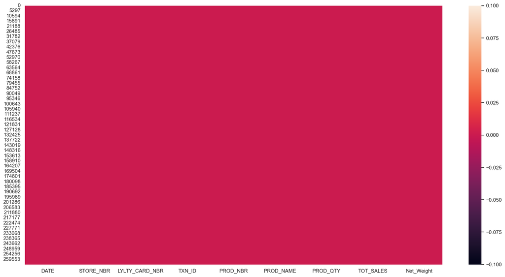

```python
# check the nan Values with visualizing it

plt.figure(figsize=(20,10))
sns.heatmap(df.isna())
```

```python
# Replace the G letter to g --------
# Note: inplace= True not working her , I used regex=True -------

#df["Net_Weight"]=df["Net_Weight"].str.replace('G', 'g', inplace=True)

df["Net_Weight"]=df["Net_Weight"].str.replace('G', 'g', regex=True)
```

```python
df["Net_Weight"].value_counts()
```

```
175g    66390
150g    43131
134g    25102
110g    22387
170g    19983
165g    15297
300g    15166
330g    12540
380g    6418
270g    6285
210g    6272
200g    4473
135g    3257
250g    3169
90g     3008
190g    2995
160g    2970
220g    1564
70g     1507
180g    1468
125g    1454
Name: Net_Weight, dtype: int64
```

```python
df.sample(50)
```

|  | DATE | STORE_NBR | LYLTY_CARD_NBR | TXN_ID | PROD_NBR | PROD_NAME | PROD_QTY | TOT_SALES | Net_Weight |
| --- | --- | --- | --- | --- | --- | --- | --- | --- | --- |
| 4977 | 2018-07-07 | 55 | 55155 | 49408 | 11 | RRD Pc Sea Salt 165g | 2 | 6.0 | 165g |
| 113770 | 2018-12-05 | 73 | 73328 | 72665 | 98 | NCC Sour Cream & Garden Chives 175g | 2 | 6.0 | 175g |
| 253336 | 2019-06-15 | 238 | 238106 | 242308 | 51 | Doritos Mexicana 170g | 1 | 4.4 | 170g |
| 247548 | 2019-06-07 | 181 | 181300 | 183803 | 81 | Pringles Original Crisps 134g | 2 | 7.4 | 134g |
| 76294 | 2018-10-14 | 88 | 88168 | 87061 | 47 | Doritos Corn Chips Original 170g | 2 | 8.8 | 170g |
| 164865 | 2019-02-13 | 56 | 56062 | 50349 | 53 | RRD Sweet Chilli & Sour Cream 165g | 2 | 6.0 | 165g |
| 240109 | 2019-05-28 | 57 | 57220 | 52554 | 26 | Pringles Sweet&Spcy BBQ 134g | 2 | 7.4 | 134g |
| 253531 | 2019-06-15 | 250 | 250192 | 252272 | 102 | Kettle Mozzarella Basil & Pesto 175g | 2 | 10.8 | 175g |
| 232719 | 2019-05-17 | 30 | 30067 | 26896 | 1 | Smiths Crinkle Cut Chips Barbecue 170g | 2 | 5.8 | 170g |
| 126096 | 2018-12-21 | 75 | 75184 | 74158 | 104 | Infuzions Thai SweetChili PotatoMix 110g | 2 | 7.6 | 110g |
| 113727 | 2018-12-04 | 120 | 120425 | 123943 | 44 | Thins Chips Light& Tangy 175g | 1 | 3.3 | 175g |
| 61169 | 2018-09-23 | 217 | 217302 | 217641 | 28 | Thins Potato Chips Hot & Spicy 175g | 2 | 6.6 | 175g |
| 183946 | 2019-03-11 | 80 | 80164 | 78905 | 112 | Tyrrells Crisps Ched & Chives 165g | 2 | 8.4 | 165g |
| 216999 | 2019-04-26 | 55 | 55086 | 48979 | 38 | Infuzions Mango Chutny Papadums 70g | 2 | 4.8 | 70g |
| 223691 | 2019-05-05 | 5 | 5007 | 4409 | 107 | Smiths Crinkle Cut French OnionDip 150g | 2 | 5.2 | 150g |
| 225374 | 2019-05-07 | 81 | 81138 | 80363 | 93 | Doritos Corn Chip Southern Chicken 150g | 2 | 7.8 | 150g |
| 178130 | 2019-03-03 | 190 | 190200 | 191431 | 82 | Smith Crinkle Cut Mac N Cheese 150g | 2 | 5.2 | 150g |
| 246244 | 2019-06-05 | 203 | 203137 | 202861 | 4 | Dorito Corn Chp Supreme 380g | 2 | 13.0 | 380g |
| 104572 | 2018-11-22 | 55 | 55224 | 49846 | 97 | RRD Salt & Vinegar 165g | 2 | 6.0 | 165g |
| 192250 | 2019-03-22 | 112 | 112123 | 114503 | 75 | Cobs Popd Sea Salt Chips 110g | 2 | 7.6 | 110g |
| 245499 | 2019-06-04 | 231 | 231241 | 234669 | 63 | Kettle 135g Swt Pot Sea Salt | 2 | 8.4 | 135g |
| 239137 | 2019-05-26 | 78 | 78238 | 76834 | 35 | Woolworths Mild Salsa 300g | 2 | 3.0 | 300g |
| 86574 | 2018-10-28 | 183 | 183158 | 185743 | 112 | Tyrrells Crisps Ched & Chives 165g | 2 | 8.4 | 165g |
| 181346 | 2019-03-08 | 226 | 226029 | 226380 | 90 | Tostitos Smoked Chipotle 175g | 2 | 8.8 | 175g |
| 234772 | 2019-05-20 | 118 | 118034 | 120875 | 71 | Twisties Cheese Burger 250g | 1 | 4.3 | 250g |
| 203090 | 2019-04-06 | 32 | 32139 | 28847 | 48 | Red Rock Deli Sp Salt & Truffle 150G | 2 | 5.4 | 150g |
| 97014 | 2018-11-11 | 32 | 32210 | 29280 | 70 | Tyrrells Crisps Lightly Salted 165g | 2 | 8.4 | 165g |
| 241766 | 2019-05-30 | 262 | 262212 | 262509 | 97 | RRD Salt & Vinegar 165g | 2 | 6.0 | 165g |
| 80994 | 2018-10-20 | 162 | 162067 | 162233 | 33 | Cobs Popd Swt/Chlli &Sr/Cream Chips 110g | 2 | 7.6 | 110g |
| 67830 | 2018-10-02 | 46 | 46086 | 41905 | 12 | Natural Chip Co Tmato Hrb&Spce 175g | 2 | 6.0 | 175g |
| 96205 | 2018-11-10 | 200 | 200013 | 199289 | 34 | Pringles Slt Vingar 134g | 2 | 7.4 | 134g |
| 230330 | 2019-05-14 | 217 | 217091 | 216726 | 49 | Infuzions SourCream&Herbs Veg Strws 110g | 1 | 3.8 | 110g |
| 83308 | 2018-10-24 | 223 | 223100 | 223519 | 67 | RRD Chilli& Coconut 150g | 2 | 5.4 | 150g |
| 163648 | 2019-02-11 | 223 | 223236 | 224360 | 55 | Snbts Whlgrn Crisps Cheddr&Mstrd 90g | 2 | 3.4 | 90g |
| 154586 | 2019-01-30 | 186 | 186287 | 188676 | 22 | Thins Chips Originl saltd 175g | 1 | 3.3 | 175g |
| 7380 | 2018-07-11 | 112 | 112073 | 114163 | 6 | RRD Lime & Pepper 165g | 2 | 6.0 | 165g |
| 120999 | 2018-12-15 | 172 | 172119 | 173468 | 92 | WW Crinkle Cut Chicken 175g | 2 | 3.4 | 175g |
| 256675 | 2019-06-19 | 221 | 221047 | 220237 | 59 | Old El Paso Salsa Dip Tomato Med 300g | 2 | 10.2 | 300g |
| 104092 | 2018-11-21 | 13 | 13246 | 12675 | 114 | Kettle Sensations Siracha Lime 150g | 2 | 9.2 | 150g |
| 40953 | 2018-08-26 | 149 | 149378 | 149141 | 74 | Tostitos Splash Of Lime 175g | 2 | 8.8 | 175g |
| 116643 | 2018-12-09 | 170 | 170282 | 172031 | 93 | Doritos Corn Chip Southern Chicken 150g | 2 | 7.8 | 150g |
| 111701 | 2018-12-02 | 128 | 128054 | 130847 | 56 | Cheezels Cheese Box 125g | 2 | 4.2 | 125g |
| 163439 | 2019-02-11 | 148 | 148106 | 147577 | 87 | Infuzions BBQ Rib Prawn Crackers 110g | 2 | 7.6 | 110g |
| 65979 | 2018-09-30 | 261 | 261006 | 259729 | 109 | Pringles Barbeque 134g | 2 | 7.4 | 134g |
| 56481 | 2018-09-16 | 65 | 65111 | 62124 | 26 | Pringles Sweet&Spcy BBQ 134g | 2 | 7.4 | 134g |
| 209179 | 2019-04-15 | 80 | 80158 | 78888 | 46 | Kettle Original 175g | 2 | 10.8 | 175g |
| 164559 | 2019-02-12 | 129 | 129209 | 133481 | 47 | Doritos Corn Chips Original 170g | 2 | 8.8 | 170g |
| 134654 | 2019-01-02 | 160 | 160177 | 161241 | 92 | WW Crinkle Cut Chicken 175g | 2 | 3.4 | 175g |
| 209491 | 2019-04-15 | 209 | 209096 | 208016 | 73 | Smiths Crinkle Cut Salt & Vinegar 170g | 2 | 5.8 | 170g |
| 98160 | 2018-11-13 | 229 | 229031 | 230542 | 40 | Thins Chips Seasonedchicken 175g | 2 | 6.6 | 175g |

```
array([<AxesSubplot:>, <AxesSubplot:>, <AxesSubplot:>, <AxesSubplot:>,
       <AxesSubplot:>, <AxesSubplot:>, <AxesSubplot:>], dtype=object)
```

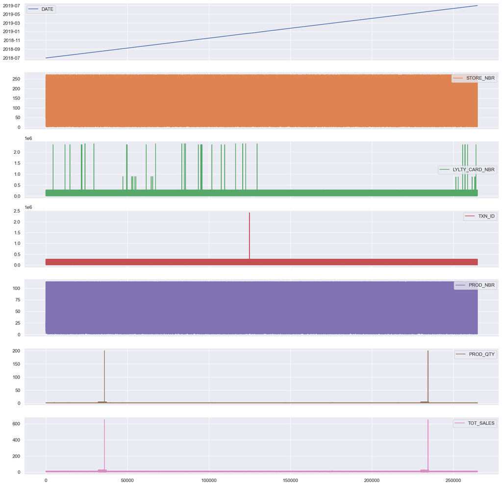

```python
# check the outlier values for the numerical data by using visualizing-----

df.plot(subplots= True, figsize=(20,20))
```

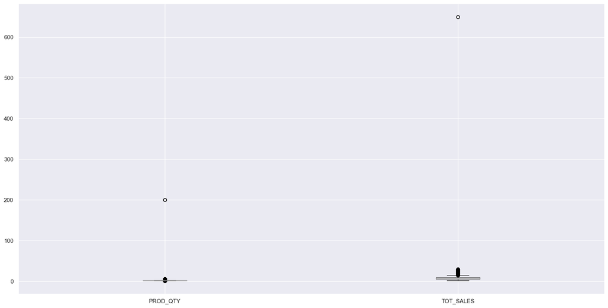

```python
#df.boxplot(column=['PROD_QTY', 'TOT_SALES'])

df.boxplot(['PROD_QTY', 'TOT_SALES'], figsize=(20,10))
```

```python
df[['PROD_QTY', 'TOT_SALES']].nunique()  # --- 30 unique values
```

```
PROD_QTY     6
TOT_SALES    112
dtype: int64
```

```python
df['TOT_SALES'].duplicated().value_counts()
```

```
True     264724
False    112
Name: TOT_SALES, dtype: int64
```

```python
df['PROD_QTY'].drop_duplicates()
```

```
0        2
10       1
5274     3
32124    4
32158    5
35936    200
Name: PROD_QTY, dtype: int64
```

```python
df[df['TOT_SALES'] == 650]
```

|  | DATE | STORE_NBR | LYLTY_CARD_NBR | TXN_ID | PROD_NBR | PROD_NAME | PROD_QTY | TOT_SALES | Net_Weight |
| --- | --- | --- | --- | --- | --- | --- | --- | --- | --- |
| 35936 | 2018-08-19 | 226 | 226000 | 226201 | 4 | Dorito Corn Chp Supreme 380g | 200 | 650.0 | 380g |
| 234487 | 2019-05-20 | 226 | 226000 | 226210 | 4 | Dorito Corn Chp Supreme 380g | 200 | 650.0 | 380g |

After discover the two outlier values in two columns "PROD_QTY" = 200 and 'TOT_SALES' = 650, and check the averge of sales by the ["PROD_NAME"] == "Dorito Corn Chp Supreme 380g"

I found that the "PROD_QTY" between 1 or 2 and the TOT_SALES' between 6.5 and 13

So, I will change the two outliers values in two columns 2 instead 200 and 6.5 instead 650

```python
# replace vlaues in columns "PROD_QTY" = 200  and 'TOT_SALES' = 650 ----

df["PROD_QTY"]=df["PROD_QTY"].replace(200, 2)
df["TOT_SALES"]=df["TOT_SALES"].replace(650, 6.50)
```

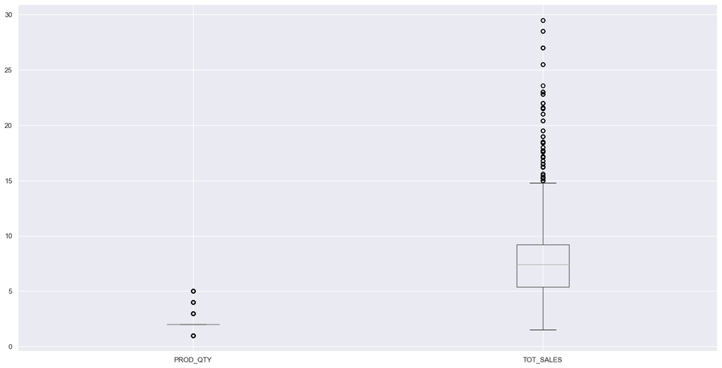

```python
#Double check the outliers after replace "PROD_QTY" = 200  and 'TOT_SALES' = 650

df.boxplot(['PROD_QTY', 'TOT_SALES'], figsize=(20,10))
```

```python
df[['PROD_QTY','TOT_SALES']].describe().round (2)
```

|  | PROD_QTY | TOT_SALES |
| --- | --- | --- |
| count | 264836.00 | 264836.00 |
| mean | 1.91 | 7.30 |
| std | 0.34 | 2.53 |
| min | 1.00 | 1.50 |
| 25% | 2.00 | 5.40 |
| 50% | 2.00 | 7.40 |
| 75% | 2.00 | 9.20 |
| max | 5.00 | 29.50 |

```python
df[df['TOT_SALES'] == 29.5]
```

|  | DATE | STORE_NBR | LYLTY_CARD_NBR | TXN_ID | PROD_NBR | PROD_NAME | PROD_QTY | TOT_SALES | Net_Weight |
| --- | --- | --- | --- | --- | --- | --- | --- | --- | --- |
| 32805 | 2018-08-15 | 94 | 94148 | 93390 | 14 | Smiths Crnkle Chip Orgnl Big Bag 380g | 5 | 29.5 | 380g |
| 32975 | 2018-08-15 | 49 | 49303 | 45789 | 14 | Smiths Crnkle Chip Orgnl Big Bag 380g | 5 | 29.5 | 380g |
| 34767 | 2018-08-17 | 24 | 24095 | 20797 | 14 | Smiths Crnkle Chip Orgnl Big Bag 380g | 5 | 29.5 | 380g |
| 230119 | 2019-05-14 | 190 | 190113 | 190914 | 14 | Smiths Crnkle Chip Orgnl Big Bag 380g | 5 | 29.5 | 380g |
| 233867 | 2019-05-19 | 194 | 194308 | 194516 | 14 | Smiths Crnkle Chip Orgnl Big Bag 380g | 5 | 29.5 | 380g |
| 234731 | 2019-05-20 | 118 | 118021 | 120799 | 14 | Smiths Crnkle Chip Orgnl Big Bag 380g | 5 | 29.5 | 380g |
| 234801 | 2019-05-20 | 44 | 44350 | 40394 | 14 | Smiths Crnkle Chip Orgnl Big Bag 380g | 5 | 29.5 | 380g |

```python
df[df['PROD_QTY'] == 5]
```

|  | DATE | STORE_NBR | LYLTY_CARD_NBR | TXN_ID | PROD_NBR | PROD_NAME | PROD_QTY | TOT_SALES | Net_Weight |
| --- | --- | --- | --- | --- | --- | --- | --- | --- | --- |
| 32158 | 2018-08-14 | 138 | 138222 | 141917 | 54 | CCs Original 175g | 5 | 10.5 | 175g |
| 32159 | 2018-08-14 | 149 | 149267 | 148970 | 102 | Kettle Mozzarella Basil & Pesto 175g | 5 | 27.0 | 175g |
| 32163 | 2018-08-14 | 157 | 157183 | 159545 | 92 | WW Crinkle Cut Chicken 175g | 5 | 8.5 | 175g |
| 32208 | 2018-08-14 | 94 | 94255 | 94107 | 2 | Cobs Popd Sour Crm &Chives Chips 110g | 5 | 19.0 | 110g |
| 32221 | 2018-08-14 | 155 | 155087 | 155558 | 101 | Doritos Salsa Medium 300g | 5 | 13.0 | 300g |
| ... | ... | ... | ... | ... | ... | ... | ... | ... | ... |
| 234818 | 2019-05-20 | 162 | 162200 | 163005 | 64 | Red Rock Deli SR Salsa & Mzzrlla 150g | 5 | 13.5 | 150g |
| 234826 | 2019-05-20 | 207 | 207126 | 205349 | 28 | Thins Potato Chips Hot & Spicy 175g | 5 | 16.5 | 175g |
| 234846 | 2019-05-20 | 24 | 24105 | 20857 | 6 | RRD Lime & Pepper 165g | 5 | 15.0 | 165g |
| 234871 | 2019-05-20 | 3 | 3025 | 1207 | 99 | Pringles Sthrn FriedChicken 134g | 5 | 7.4 | 134g |
| 234962 | 2019-05-20 | 116 | 116059 | 119486 | 9 | Kettle Tortilla ChpsBtroot&Ricotta 150g | 5 | 23.0 | 150g |

450 rows × 9 columns

```python
Q1=df.quantile(.25).round(2)
Q1
```

```
STORE_NBR         70.0
LYLTY_CARD_NBR    70021.0
TXN_ID            67601.5
PROD_NBR          28.0
PROD_QTY          2.0
TOT_SALES         5.4
Name: 0.25, dtype: float64
```

```python
Q3=df.quantile(.75).round(2)
Q3
```

```
STORE_NBR         203.00
LYLTY_CARD_NBR    203094.25
TXN_ID            202701.25
PROD_NBR          85.00
PROD_QTY          2.00
TOT_SALES         9.20
Name: 0.75, dtype: float64
```

```python
IQR= Q3-Q1
```

```python
Lower_limit= Q1-(1.5*IQR)
Higher_limit= Q3+(1.5* IQR)
```

```python
Lower_limit
```

```
STORE_NBR        -129.500
LYLTY_CARD_NBR   -129588.875
TXN_ID           -135048.125
PROD_NBR         -57.500
PROD_QTY          2.000
TOT_SALES        -0.300
dtype: float64
```

```python
Higher_limit
```

```
STORE_NBR         402.500
LYLTY_CARD_NBR    402704.125
TXN_ID            405350.875
PROD_NBR          170.500
PROD_QTY          2.000
TOT_SALES         14.900
dtype: float64
```

```python
df[df['TOT_SALES'] > 14.900]
```

|  | DATE | STORE_NBR | LYLTY_CARD_NBR | TXN_ID | PROD_NBR | PROD_NAME | PROD_QTY | TOT_SALES | Net_Weight |
| --- | --- | --- | --- | --- | --- | --- | --- | --- | --- |
| 13639 | 2018-07-19 | 105 | 105127 | 106050 | 23 | Cheezels Cheese 330g | 3 | 17.1 | 330g |
| 32109 | 2018-08-14 | 217 | 217294 | 217612 | 89 | Kettle Sweet Chilli And Sour Cream 175g | 3 | 16.2 | 175g |
| 32124 | 2018-08-14 | 27 | 27179 | 24216 | 20 | Doritos Cheese Supreme 330g | 4 | 22.8 | 330g |
| 32136 | 2018-08-14 | 72 | 72201 | 71483 | 65 | Old El Paso Salsa Dip Chnky Tom Ht300g | 3 | 15.3 | 300g |
| 32159 | 2018-08-14 | 149 | 149267 | 148970 | 102 | Kettle Mozzarella Basil & Pesto 175g | 5 | 27.0 | 175g |
| ... | ... | ... | ... | ... | ... | ... | ... | ... | ... |
| 234852 | 2019-05-20 | 104 | 104223 | 105099 | 16 | Smiths Crinkle Chips Salt & Vinegar 330g | 4 | 22.8 | 330g |
| 234865 | 2019-05-20 | 213 | 213148 | 212870 | 2 | Cobs Popd Sour Crm &Chives Chips 110g | 4 | 15.2 | 110g |
| 234934 | 2019-05-20 | 269 | 269173 | 266088 | 57 | Old El Paso Salsa Dip Tomato Mild 300g | 3 | 15.3 | 300g |
| 234955 | 2019-05-20 | 82 | 82223 | 81709 | 108 | Kettle Tortilla ChpsHny&Jlpno Chili 150g | 4 | 18.4 | 150g |
| 234962 | 2019-05-20 | 116 | 116059 | 119486 | 9 | Kettle Tortilla ChpsBtroot&Ricotta 150g | 5 | 23.0 | 150g |

576 rows × 9 columns

```python
df[(df['TOT_SALES'] <=14.900) & (df['TOT_SALES'] > -0.300 )]
```

|  | DATE | STORE_NBR | LYLTY_CARD_NBR | TXN_ID | PROD_NBR | PROD_NAME | PROD_QTY | TOT_SALES | Net_Weight |
| --- | --- | --- | --- | --- | --- | --- | --- | --- | --- |
| 0 | 2018-07-01 | 47 | 47142 | 42540 | 14 | Smiths Crnkle Chip Orgnl Big Bag 380g | 2 | 11.8 | 380g |
| 1 | 2018-07-01 | 55 | 55073 | 48884 | 99 | Pringles Sthrn FriedChicken 134g | 2 | 7.4 | 134g |
| 2 | 2018-07-01 | 55 | 55073 | 48884 | 91 | CCs Tasty Cheese 175g | 2 | 4.2 | 175g |
| 3 | 2018-07-01 | 58 | 58351 | 54374 | 102 | Kettle Mozzarella Basil & Pesto 175g | 2 | 10.8 | 175g |
| 4 | 2018-07-01 | 68 | 68193 | 65598 | 44 | Thins Chips Light& Tangy 175g | 2 | 6.6 | 175g |
| ... | ... | ... | ... | ... | ... | ... | ... | ... | ... |
| 264831 | 2019-06-30 | 242 | 242159 | 246222 | 36 | Kettle Chilli 175g | 2 | 10.8 | 175g |
| 264832 | 2019-06-30 | 244 | 244213 | 247339 | 93 | Doritos Corn Chip Southern Chicken 150g | 2 | 7.8 | 150g |
| 264833 | 2019-06-30 | 256 | 256018 | 255130 | 105 | Woolworths Cheese Rings 190g | 2 | 3.6 | 190g |
| 264834 | 2019-06-30 | 257 | 257079 | 256218 | 71 | Twisties Cheese Burger 250g | 2 | 8.6 | 250g |
| 264835 | 2019-06-30 | 265 | 265006 | 263307 | 106 | Natural ChipCo Hony Soy Chckn175g | 1 | 3.0 | 175g |

264260 rows × 9 columns

## Descover the buying_behaviour data

```python
df_QVI_behaviour
```

|  | LYLTY_CARD_NBR | LIFESTAGE | PREMIUM_CUSTOMER |
| --- | --- | --- | --- |
| 0 | 1000 | YOUNG SINGLES/COUPLES | Premium |
| 1 | 1002 | YOUNG SINGLES/COUPLES | Mainstream |
| 2 | 1003 | YOUNG FAMILIES | Budget |
| 3 | 1004 | OLDER SINGLES/COUPLES | Mainstream |
| 4 | 1005 | MIDAGE SINGLES/COUPLES | Mainstream |
| ... | ... | ... | ... |
| 72632 | 2370651 | MIDAGE SINGLES/COUPLES | Mainstream |
| 72633 | 2370701 | YOUNG FAMILIES | Mainstream |
| 72634 | 2370751 | YOUNG FAMILIES | Premium |
| 72635 | 2370961 | OLDER FAMILIES | Budget |
| 72636 | 2373711 | YOUNG SINGLES/COUPLES | Mainstream |

72637 rows × 3 columns

```python
df_QVI_behaviour.info()
```

```
<class 'pandas.core.frame.DataFrame'>
RangeIndex: 72637 entries, 0 to 72636
Data columns (total 3 columns):
 #   Column            Non-Null Count  Dtype
---  ------            --------------  -----
 0   LYLTY_CARD_NBR    72637 non-null  int64
 1   LIFESTAGE         72637 non-null  object
 2   PREMIUM_CUSTOMER  72637 non-null  object
dtypes: int64(1), object(2)
memory usage: 1.7+ MB
```

```python
# check the Nan Values numbers -----
df_QVI_behaviour.count()
```

```
LYLTY_CARD_NBR      72637
LIFESTAGE           72637
PREMIUM_CUSTOMER    72637
dtype: int64
```

```python
# Check All unique PREMIUM_CUSTOMER  -----------

df_QVI_behaviour["PREMIUM_CUSTOMER"].drop_duplicates()
```

```
0    Premium
1    Mainstream
2    Budget
Name: PREMIUM_CUSTOMER, dtype: object
```

```python
# Check All unique LIFESTAGE -----------

df_QVI_behaviour["LIFESTAGE"].drop_duplicates()
```

```
0     YOUNG SINGLES/COUPLES
2     YOUNG FAMILIES
3     OLDER SINGLES/COUPLES
4     MIDAGE SINGLES/COUPLES
6     NEW FAMILIES
9     OLDER FAMILIES
10    RETIREES
Name: LIFESTAGE, dtype: object
```

## Merge two data frame -----

```python
# Merge two data frame and drop 'TXN_ID','PROD_NBR' I don't use it  -----------

merge_data= df.drop(['TXN_ID','PROD_NBR'], axis=1).merge(df_QVI_behaviour)
```

```python
merge_data
```

|  | DATE | STORE_NBR | LYLTY_CARD_NBR | PROD_NAME | PROD_QTY | TOT_SALES | Net_Weight | LIFESTAGE | PREMIUM_CUSTOMER |
| --- | --- | --- | --- | --- | --- | --- | --- | --- | --- |
| 0 | 2018-07-01 | 47 | 47142 | Smiths Crnkle Chip Orgnl Big Bag 380g | 2 | 11.8 | 380g | MIDAGE SINGLES/COUPLES | Budget |
| 1 | 2018-07-01 | 55 | 55073 | Pringles Sthrn FriedChicken 134g | 2 | 7.4 | 134g | MIDAGE SINGLES/COUPLES | Budget |
| 2 | 2018-07-01 | 55 | 55073 | CCs Tasty Cheese 175g | 2 | 4.2 | 175g | MIDAGE SINGLES/COUPLES | Budget |
| 3 | 2018-08-05 | 55 | 55073 | Pringles Barbeque 134g | 2 | 7.4 | 134g | MIDAGE SINGLES/COUPLES | Budget |
| 4 | 2018-09-02 | 55 | 55073 | Kettle Sweet Chilli And Sour Cream 175g | 2 | 10.8 | 175g | MIDAGE SINGLES/COUPLES | Budget |
| ... | ... | ... | ... | ... | ... | ... | ... | ... | ... |
| 264831 | 2019-06-30 | 265 | 265221 | Doritos Cheese Supreme 330g | 1 | 5.7 | 330g | YOUNG SINGLES/COUPLES | Mainstream |
| 264832 | 2019-06-30 | 6 | 6358 | Infuzions BBQ Rib Prawn Crackers 110g | 1 | 3.8 | 110g | YOUNG SINGLES/COUPLES | Premium |
| 264833 | 2019-06-30 | 169 | 169080 | Smiths Crinkle Cut Chips Barbecue 170g | 2 | 5.8 | 170g | YOUNG SINGLES/COUPLES | Premium |
| 264834 | 2019-06-30 | 244 | 244213 | Doritos Corn Chip Southern Chicken 150g | 2 | 7.8 | 150g | YOUNG SINGLES/COUPLES | Premium |
| 264835 | 2019-06-30 | 265 | 265006 | Natural ChipCo Hony Soy Chckn175g | 1 | 3.0 | 175g | YOUNG SINGLES/COUPLES | Premium |

264836 rows × 9 columns

```python
merge_data.info()
```

```
<class 'pandas.core.frame.DataFrame'>
Int64Index: 264836 entries, 0 to 264835
Data columns (total 9 columns):
 #   Column            Non-Null Count   Dtype
---  ------            --------------   -----
 0   DATE              264836 non-null  datetime64[ns]
 1   STORE_NBR         264836 non-null  int64
 2   LYLTY_CARD_NBR    264836 non-null  int64
 3   PROD_NAME         264836 non-null  object
 4   PROD_QTY          264836 non-null  int64
 5   TOT_SALES         264836 non-null  float64
 6   Net_Weight        264836 non-null  object
 7   LIFESTAGE         264836 non-null  object
 8   PREMIUM_CUSTOMER  264836 non-null  object
dtypes: datetime64[ns](1), float64(1), int64(3), object(4)
memory usage: 20.2+ MB
```

```python
merge_data.isnull().sum()
```

```
DATE                0
STORE_NBR           0
LYLTY_CARD_NBR      0
PROD_NAME           0
PROD_QTY            0
TOT_SALES           0
Net_Weight          0
LIFESTAGE           0
PREMIUM_CUSTOMER    0
dtype: int64
```

```
array([<AxesSubplot:>, <AxesSubplot:>, <AxesSubplot:>, <AxesSubplot:>,
       <AxesSubplot:>], dtype=object)
```

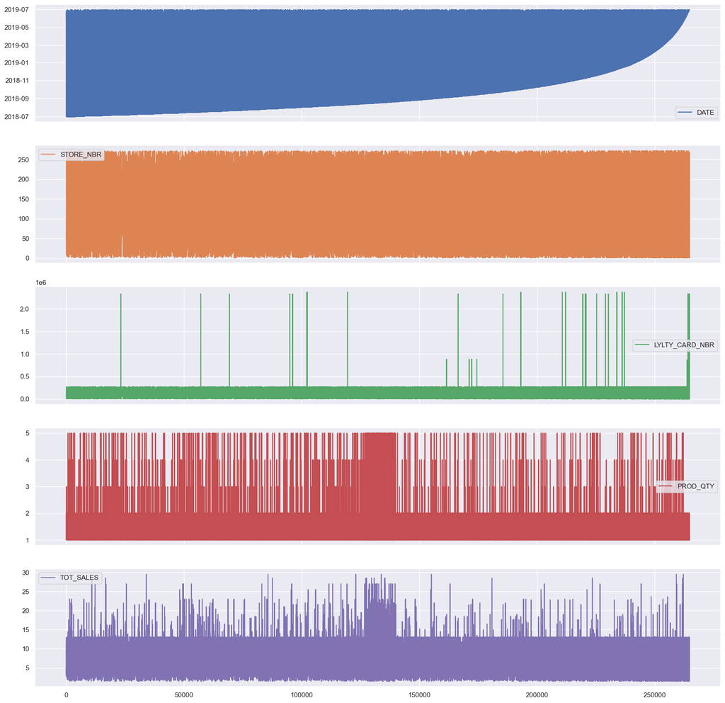

```python
# check the outlier values for the numerical data by using visualizing-----

merge_data.plot(subplots= True, figsize=(20,20))
```

```python
# Change the index by the date ----------

# Note: I get error --"None of ['DATE'] are in the columns" -- but the code is run correctly

# the code ---
merge_data.set_index("DATE", inplace=True)
```

```python
merge_data
```

| DATE | STORE_NBR | LYLTY_CARD_NBR | PROD_NAME | PROD_QTY | TOT_SALES | Net_Weight | LIFESTAGE | PREMIUM_CUSTOMER |
| --- | --- | --- | --- | --- | --- | --- | --- | --- |
| 2018-07-01 | 47 | 47142 | Smiths Crnkle Chip Orgnl Big Bag 380g | 2 | 11.8 | 380g | MIDAGE SINGLES/COUPLES | Budget |
| 2018-07-01 | 55 | 55073 | Pringles Sthrn FriedChicken 134g | 2 | 7.4 | 134g | MIDAGE SINGLES/COUPLES | Budget |
| 2018-07-01 | 55 | 55073 | CCs Tasty Cheese 175g | 2 | 4.2 | 175g | MIDAGE SINGLES/COUPLES | Budget |
| 2018-08-05 | 55 | 55073 | Pringles Barbeque 134g | 2 | 7.4 | 134g | MIDAGE SINGLES/COUPLES | Budget |
| 2018-09-02 | 55 | 55073 | Kettle Sweet Chilli And Sour Cream 175g | 2 | 10.8 | 175g | MIDAGE SINGLES/COUPLES | Budget |
| ... | ... | ... | ... | ... | ... | ... | ... | ... |
| 2019-06-30 | 265 | 265221 | Doritos Cheese Supreme 330g | 1 | 5.7 | 330g | YOUNG SINGLES/COUPLES | Mainstream |
| 2019-06-30 | 6 | 6358 | Infuzions BBQ Rib Prawn Crackers 110g | 1 | 3.8 | 110g | YOUNG SINGLES/COUPLES | Premium |
| 2019-06-30 | 169 | 169080 | Smiths Crinkle Cut Chips Barbecue 170g | 2 | 5.8 | 170g | YOUNG SINGLES/COUPLES | Premium |
| 2019-06-30 | 244 | 244213 | Doritos Corn Chip Southern Chicken 150g | 2 | 7.8 | 150g | YOUNG SINGLES/COUPLES | Premium |
| 2019-06-30 | 265 | 265006 | Natural ChipCo Hony Soy Chckn175g | 1 | 3.0 | 175g | YOUNG SINGLES/COUPLES | Premium |

264836 rows × 8 columns

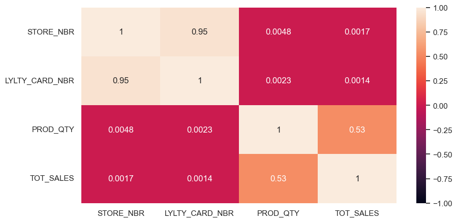

```python
# check the correlation between variables by heatmap
plt.figure(figsize=(10, 5))
sns.heatmap(merge_data.corr(), vmin=-1, vmax=1, annot=True)
```

```python
merge_data.corr()
```

|  | STORE_NBR | LYLTY_CARD_NBR | PROD_QTY | TOT_SALES |
| --- | --- | --- | --- | --- |
| STORE_NBR | 1.000000 | 0.950869 | 0.004768 | 0.001669 |
| LYLTY_CARD_NBR | 0.950869 | 1.000000 | 0.002298 | 0.001390 |
| PROD_QTY | 0.004768 | 0.002298 | 1.000000 | 0.527787 |
| TOT_SALES | 0.001669 | 0.001390 | 0.527787 | 1.000000 |

Based on the correlation, there is a strong correlation between STORE_NBR ( Store ) and the number of customers (LYLTY_CARD_NBR) Also, the correlation between the sales (TOT_SALES) and customer numbers (LYLTY_CARD_NBR) is shallow, it means that the numbers of customers doesn't indicate the store gains high sales based on the number of their customers.

```python
# total sales revenue----

merge_data['TOT_SALES'].sum().round(2)
```

```
1933128.0
```

```python
# total number of customers is 72637 ----

merge_data["LYLTY_CARD_NBR"].nunique()
```

```
72637
```

```python
merge_data["LYLTY_CARD_NBR"].drop_duplicates()
```

```
DATE
2018-07-01    47142
2018-07-01    55073
2018-07-01    58351
2018-07-01    68193
2018-07-01    69207
              ...
2019-06-30    265221
2019-06-30    6358
2019-06-30    169080
2019-06-30    244213
2019-06-30    265006
Name: LYLTY_CARD_NBR, Length: 72637, dtype: int64
```

### Highest and lowest sales stores of the year -----

```python
store_Sales= merge_data.groupby("STORE_NBR")["TOT_SALES"].sum().sort_values(ascending=False)

store_Sales
```

```
STORE_NBR
226    17618.45
88     16333.25
165    15973.75
40     15559.50
237    15539.50
58     15251.45
199    14797.00
4      14647.65
203    14551.60
26     14469.30
81     14361.95
201    14298.70
130    14289.65
72     14204.40
```

[output cut: 259 more lines]

```python
store_Sales.nlargest(10,'all')
```

```
STORE_NBR
226    17618.45
88     16333.25
165    15973.75
40     15559.50
237    15539.50
58     15251.45
199    14797.00
4      14647.65
203    14551.60
26     14469.30
Name: TOT_SALES, dtype: float64
```

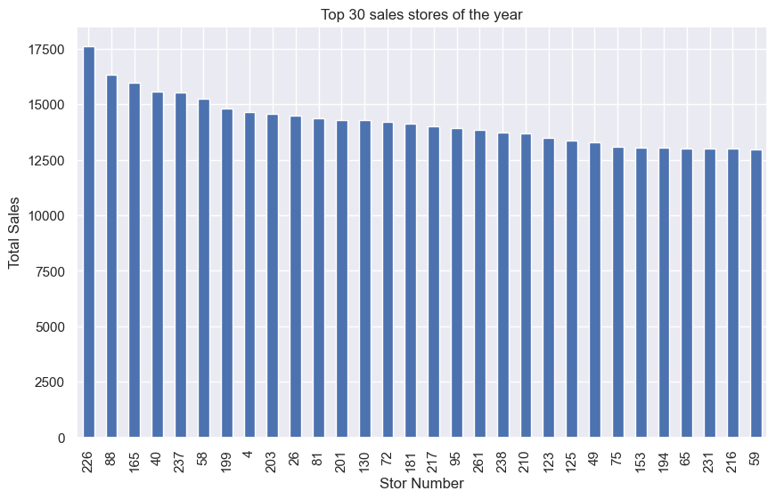

```python
store_Sales.nlargest(30,'all').plot(kind='bar',figsize=(10, 6), title='Top 30 sales stores of the year',
                                            ylabel='Total Sales', xlabel='Stor Number')
```

```python
store_Sales.nsmallest(10,'all')
```

```
STORE_NBR
211    5.2
76     6.0
11     6.7
252    7.4
206    7.6
92     9.2
193    13.1
85     13.9
31     14.8
117    161.8
Name: TOT_SALES, dtype: float64
```

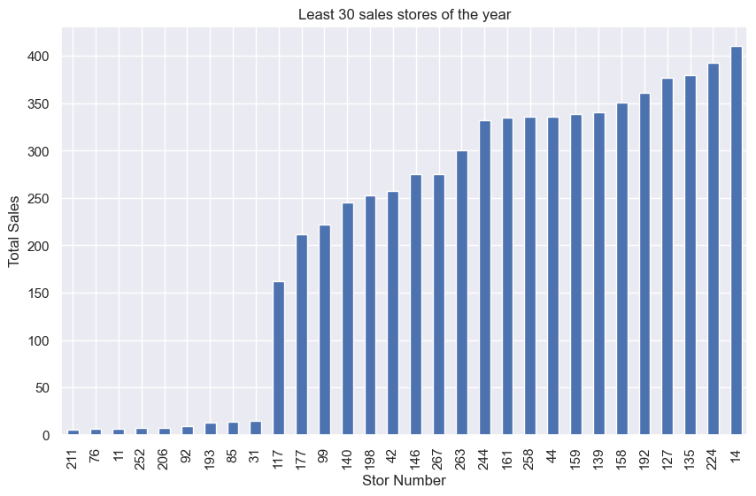

```python
store_Sales.nsmallest(30,'all').plot(kind='bar',figsize=(10, 6), title='Least 30 sales stores of the year',
                                            ylabel='Total Sales', xlabel='Stor Number')
```

### Highest and lowest sales Products of the year -----

```python
Products_Sales= merge_data.groupby("PROD_NAME")["TOT_SALES"].sum().sort_values(ascending=False)
Products_Sales
```

```
PROD_NAME
Dorito Corn Chp Supreme 380g                39065.0
Smiths Crnkle Chip Orgnl Big Bag 380g       36367.6
Smiths Crinkle Chips Salt & Vinegar 330g    34804.2
Kettle Mozzarella Basil & Pesto 175g        34457.4
Smiths Crinkle Original 330g                34302.6
Cheezels Cheese 330g                        34296.9
Doritos Cheese Supreme 330g                 33390.6
Kettle Sweet Chilli And Sour Cream 175g     33031.8
Kettle Original 175g                        32740.2
Kettle Sea Salt And Vinegar 175g            32589.0
Kettle Honey Soy Chicken 175g               32578.2
Kettle Chilli 175g                          31271.4
Old El Paso Salsa Dip Chnky Tom Ht300g      30513.3
Old El Paso Salsa Dip Tomato Med 300g       30237.9
Old El Paso Salsa Dip Tomato Mild 300g      30033.9
Kettle Tortilla ChpsHny&Jlpno Chili 150g    29021.4
Kettle Sensations Camembert & Fig 150g      28308.4
Twisties Chicken270g                        27853.0
Kettle Tortilla ChpsBtroot&Ricotta 150g     27770.2
Kettle Tortilla ChpsFeta&Garlic 150g        27627.6
Twisties Cheese 270g                        27572.4
Kettle Sensations Siracha Lime 150g         27567.8
Tostitos Splash Of Lime 175g                27429.6
Kettle Sensations BBQ&Maple 150g            27186.0
Doritos Corn Chips Cheese Supreme 170g      27183.2
Doritos Corn Chips Nacho Cheese 170g        26562.8
Tostitos Smoked Chipotle 175g               26474.8
Doritos Mexicana 170g                       26290.0
Doritos Corn Chips Original 170g            26228.4
Tyrrells Crisps Ched & Chives 165g          26149.2
Twisties Cheese Burger 250g                 26096.7
Kettle 135g Swt Pot Sea Salt                26090.4
Tostitos Lightly Salted 175g                25885.2
Tyrrells Crisps Lightly Salted 165g         25498.2
Doritos Corn Chip Mexican Jalapeno 150g     23887.5
Cobs Popd Sea Salt Chips 110g               23852.6
Cobs Popd Swt/Chlli &Sr/Cream Chips 110g    23772.8
Doritos Corn Chip Southern Chicken 150g     23735.4
Infuzions Thai SweetChili PotatoMix 110g    23582.8
```

[output cut: 61 more lines]

```
CCs Nacho Cheese 175g                       5961.9
Cheezels Cheese Box 125g                    5733.0
WW Supreme Cheese Corn Chips 200g           5390.3
WW Original Corn Chips 200g                 5367.5
WW Original Stacked Chips 160g              5323.8
WW Sour Cream &OnionStacked Chips 160g      5323.8
WW D/Style Chip Sea Salt 200g               5249.7
Woolworths Cheese Rings 190g                5169.6
Snbts Whlgrn Crisps Cheddr&Mstrd 90g        5076.2
WW Crinkle Cut Chicken 175g                 4702.2
Sunbites Whlegrn Crisps Frch/Onin 90g       4600.2
WW Crinkle Cut Original 175g                4532.2
Woolworths Mild Salsa 300g                  4234.5
Woolworths Medium Salsa 300g                4050.0
Name: TOT_SALES, dtype: float64
```

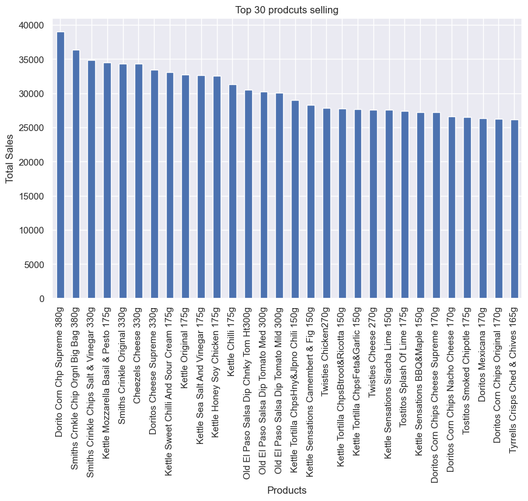

```python
Products_Sales.nlargest(30,'all').plot(kind='bar',figsize=(10, 6), title='Top 30 prodcuts selling',
                                            ylabel='Total Sales', xlabel='Products')
```

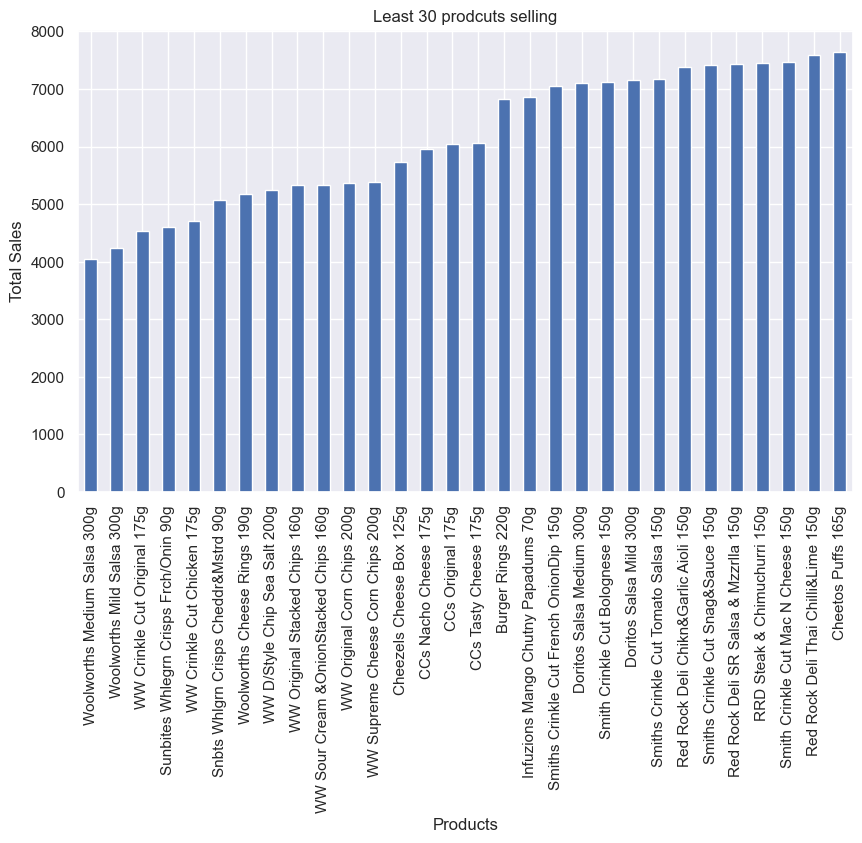

```python
Products_Sales.nsmallest(30,'all').plot(kind='bar',figsize=(10, 6), title='Least 30 prodcuts selling',
                                            ylabel='Total Sales', xlabel='Products')
```

### LIFESTAGE for all sales stores of the year -----

```python
LIFESTAGE_Sales= merge_data.groupby("LIFESTAGE")["TOT_SALES"].sum().sort_values(ascending=False)
LIFESTAGE_Sales
```

```
LIFESTAGE
OLDER SINGLES/COUPLES     402426.75
RETIREES                  366470.90
OLDER FAMILIES            352480.20
YOUNG FAMILIES            316160.10
YOUNG SINGLES/COUPLES     260405.30
MIDAGE SINGLES/COUPLES    184751.30
NEW FAMILIES              50433.45
Name: TOT_SALES, dtype: float64
```

```python
type (LIFESTAGE_Sales)
```

```
pandas.core.series.Series
```

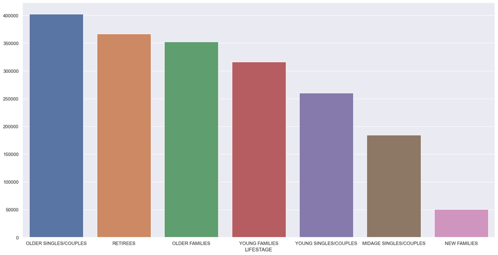

```python
fig_dim = (20, 10)
f, ax = plt.subplots(figsize = fig_dim)
sns.barplot(LIFESTAGE_Sales.index, LIFESTAGE_Sales.values, ax=ax)
```

```python
merge_data_Daily = merge_data.resample("D").agg({"TOT_SALES":"sum",
                                                "LYLTY_CARD_NBR":"count"}).sort_values(by='TOT_SALES',
                                                                                       ascending=False)
```

```python
merge_data_Daily
```

| DATE | TOT_SALES | LYLTY_CARD_NBR |
| --- | --- | --- |
| 2018-12-24 | 6923.00 | 939 |
| 2018-12-23 | 6826.00 | 917 |
| 2018-12-19 | 6639.80 | 906 |
| 2018-12-22 | 6558.70 | 915 |
| 2018-12-20 | 6300.80 | 855 |
| ... | ... | ... |
| 2018-08-20 | 4198.20 | 693 |
| 2019-05-17 | 4192.45 | 698 |
| 2019-05-15 | 4060.30 | 676 |
| 2019-05-18 | 4036.50 | 679 |
| 2018-12-25 | 0.00 | 0 |

365 rows × 2 columns

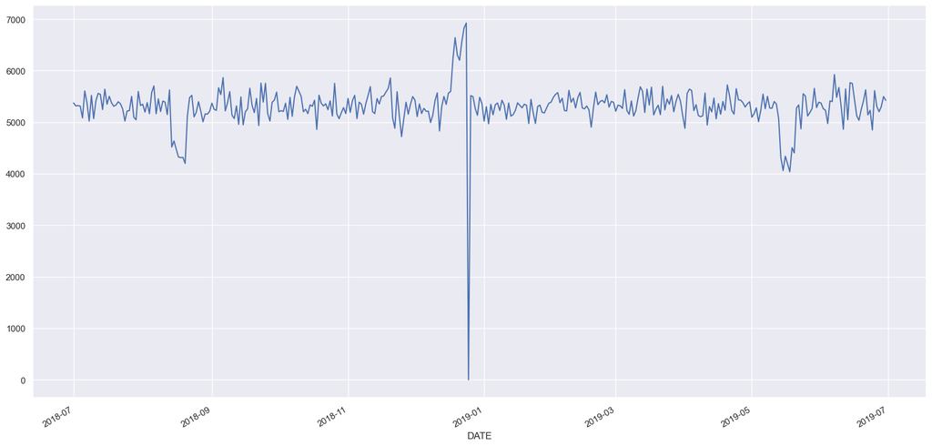

```python
# visualization of Daily total sales -------

merge_data_Daily['TOT_SALES'].plot(figsize=(20,10))
```

### Trnasactions and sales per month -------

```python
merge_data_monthly = merge_data.resample("M").agg({"TOT_SALES":"sum", "LYLTY_CARD_NBR":"count"})
merge_data_monthly
```

| DATE | TOT_SALES | LYLTY_CARD_NBR |
| --- | --- | --- |
| 2018-07-31 | 165275.30 | 22562 |
| 2018-08-31 | 158087.55 | 22411 |
| 2018-09-30 | 160522.00 | 21743 |
| 2018-10-31 | 164415.70 | 22288 |
| 2018-11-30 | 160233.70 | 21852 |
| 2018-12-31 | 167913.40 | 22835 |
| 2019-01-31 | 162642.30 | 22161 |
| 2019-02-28 | 150665.00 | 20405 |
| 2019-03-31 | 166265.20 | 22592 |
| 2019-04-30 | 159845.10 | 21766 |
| 2019-05-31 | 156724.15 | 22392 |
| 2019-06-30 | 160538.60 | 21829 |

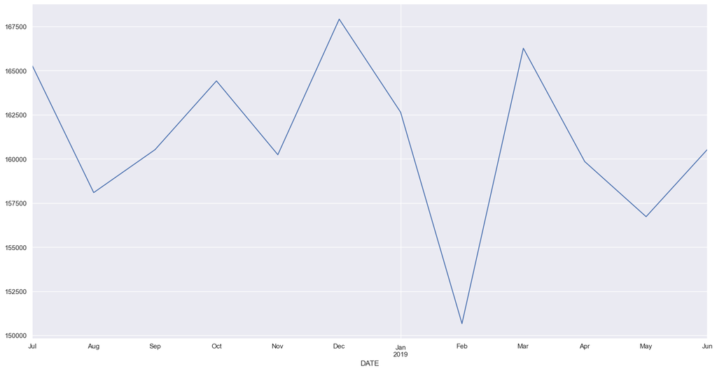

```python
merge_data_monthly['TOT_SALES'].plot(figsize=(20,10))
```

### Top customers purchasing and sales amount ----

```python
merge_data.pivot_table(index=['LYLTY_CARD_NBR'], values='TOT_SALES',
                            aggfunc= {'LYLTY_CARD_NBR':"count",
                                      'TOT_SALES': "sum"}).sort_values(by='TOT_SALES', ascending=False)
```

| LYLTY_CARD_NBR | LYLTY_CARD_NBR | TOT_SALES |
| --- | --- | --- |
| 230078 | 17 | 138.6 |
| 63197 | 15 | 132.8 |
| 259009 | 15 | 127.2 |
| 162039 | 18 | 126.8 |
| 58361 | 14 | 124.8 |
| ... | ... | ... |
| 51251 | 1 | 1.5 |
| 41089 | 1 | 1.5 |
| 2272 | 1 | 1.5 |
| 186361 | 1 | 1.5 |
| 6074 | 1 | 1.5 |

72637 rows × 2 columns

```python
# Top 30 customers purchase and transaction

merge_data.pivot_table(index=['LYLTY_CARD_NBR'], values='TOT_SALES',
                            aggfunc= {'LYLTY_CARD_NBR':"count",
                                      'TOT_SALES': "sum"}).sort_values(by='TOT_SALES', ascending=False).head(30)
```

| LYLTY_CARD_NBR | LYLTY_CARD_NBR | TOT_SALES |
| --- | --- | --- |
| 230078 | 17 | 138.60 |
| 63197 | 15 | 132.80 |
| 259009 | 15 | 127.20 |
| 162039 | 18 | 126.80 |
| 58361 | 14 | 124.80 |
| 230154 | 14 | 124.40 |
| 94185 | 16 | 122.80 |
| 130090 | 14 | 122.65 |
| 179228 | 16 | 120.80 |
| 172032 | 18 | 120.10 |
| 199157 | 13 | 118.80 |
| 116181 | 17 | 117.60 |
| 114163 | 15 | 117.40 |
| 3153 | 13 | 116.40 |
| 59333 | 13 | 116.20 |
| 28020 | 15 | 115.60 |
| 164034 | 15 | 115.60 |
| 116113 | 14 | 115.40 |
| 156054 | 15 | 115.40 |
| 199146 | 13 | 115.20 |
| 95048 | 13 | 115.10 |
| 5168 | 14 | 114.80 |
| 23192 | 16 | 114.70 |
| 257202 | 15 | 114.30 |
| 105026 | 16 | 114.20 |
| 180111 | 14 | 114.00 |
| 32060 | 15 | 114.00 |
| 109036 | 16 | 113.00 |
| 201294 | 13 | 113.00 |
| 152094 | 15 | 112.10 |

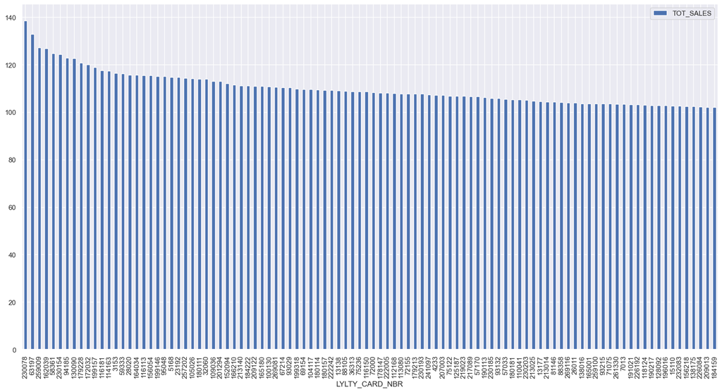

```python
# Top 100 customers purchasing -----

merge_data.pivot_table(index=['LYLTY_CARD_NBR'], values='TOT_SALES',
                            aggfunc= {'TOT_SALES': "sum"}).sort_values(by='TOT_SALES',
                                                                       ascending=False).head(100).plot(kind= "bar",figsize=(20,10))
```

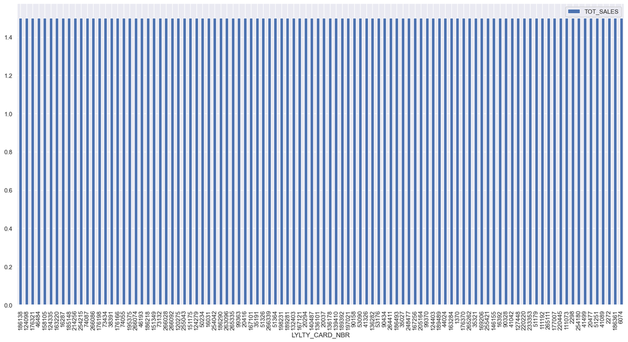

```python
# Lowest 100 customers purchasing -----

merge_data.pivot_table(index=['LYLTY_CARD_NBR'], values='TOT_SALES',
                            aggfunc= {'TOT_SALES': "sum"}).sort_values(by='TOT_SALES',
                                                                       ascending=False).tail(100).plot(kind= "bar",figsize=(20,10))
```

### Average of total purchase per customer ----

```python
# average of total purchase per customer ----

average_purchase_cus= merge_data.pivot_table(index=['LYLTY_CARD_NBR'], values='TOT_SALES',
                            aggfunc= {'LYLTY_CARD_NBR':"count",
                                      'TOT_SALES': "sum"}).sort_values(by= 'TOT_SALES', ascending=False)

average_purchase_cus.rename(columns = {'LYLTY_CARD_NBR':'Transaction_Numbers'}, inplace = True)

average_purchase_cus
```

| LYLTY_CARD_NBR | Transaction_Numbers | TOT_SALES |
| --- | --- | --- |
| 230078 | 17 | 138.6 |
| 63197 | 15 | 132.8 |
| 259009 | 15 | 127.2 |
| 162039 | 18 | 126.8 |
| 58361 | 14 | 124.8 |
| ... | ... | ... |
| 51251 | 1 | 1.5 |
| 41089 | 1 | 1.5 |
| 2272 | 1 | 1.5 |
| 186361 | 1 | 1.5 |
| 6074 | 1 | 1.5 |

72637 rows × 2 columns

```python
average_purchase_cus["the_average"]= average_purchase_cus['TOT_SALES']/average_purchase_cus['Transaction_Numbers']

average_purchase_cus.round(2)
```

| LYLTY_CARD_NBR | Transaction_Numbers | TOT_SALES | the_average |
| --- | --- | --- | --- |
| 230078 | 17 | 138.6 | 8.15 |
| 63197 | 15 | 132.8 | 8.85 |
| 259009 | 15 | 127.2 | 8.48 |
| 162039 | 18 | 126.8 | 7.04 |
| 58361 | 14 | 124.8 | 8.91 |
| ... | ... | ... | ... |
| 51251 | 1 | 1.5 | 1.50 |
| 41089 | 1 | 1.5 | 1.50 |
| 2272 | 1 | 1.5 | 1.50 |
| 186361 | 1 | 1.5 | 1.50 |
| 6074 | 1 | 1.5 | 1.50 |

72637 rows × 3 columns

```python
average_purchase_cus.nlargest(50,'TOT_SALES').round(2)
```

| LYLTY_CARD_NBR | Transaction_Numbers | TOT_SALES | the_average |
| --- | --- | --- | --- |
| 230078 | 17 | 138.60 | 8.15 |
| 63197 | 15 | 132.80 | 8.85 |
| 259009 | 15 | 127.20 | 8.48 |
| 162039 | 18 | 126.80 | 7.04 |
| 58361 | 14 | 124.80 | 8.91 |
| 230154 | 14 | 124.40 | 8.89 |
| 94185 | 16 | 122.80 | 7.68 |
| 130090 | 14 | 122.65 | 8.76 |
| 179228 | 16 | 120.80 | 7.55 |
| 172032 | 18 | 120.10 | 6.67 |
| 199157 | 13 | 118.80 | 9.14 |
| 116181 | 17 | 117.60 | 6.92 |
| 114163 | 15 | 117.40 | 7.83 |
| 3153 | 13 | 116.40 | 8.95 |
| 59333 | 13 | 116.20 | 8.94 |
| 28020 | 15 | 115.60 | 7.71 |
| 164034 | 15 | 115.60 | 7.71 |
| 116113 | 14 | 115.40 | 8.24 |
| 156054 | 15 | 115.40 | 7.69 |
| 199146 | 13 | 115.20 | 8.86 |
| 95048 | 13 | 115.10 | 8.85 |
| 5168 | 14 | 114.80 | 8.20 |
| 23192 | 16 | 114.70 | 7.17 |
| 257202 | 15 | 114.30 | 7.62 |
| 105026 | 16 | 114.20 | 7.14 |
| 180111 | 14 | 114.00 | 8.14 |
| 32060 | 15 | 114.00 | 7.60 |
| 109036 | 16 | 113.00 | 7.06 |
| 201294 | 13 | 113.00 | 8.69 |
| 152094 | 15 | 112.10 | 7.47 |
| 166210 | 13 | 111.60 | 8.58 |
| 213140 | 16 | 111.20 | 6.95 |
| 184222 | 13 | 111.20 | 8.55 |
| 209122 | 15 | 111.00 | 7.40 |
| 165180 | 13 | 110.90 | 8.53 |
| 100130 | 15 | 110.80 | 7.39 |
| 269081 | 13 | 110.60 | 8.51 |
| 67214 | 14 | 110.40 | 7.89 |
| 93029 | 14 | 110.40 | 7.89 |
| 199318 | 12 | 109.90 | 9.16 |
| 69154 | 13 | 109.60 | 8.43 |
| 104117 | 16 | 109.60 | 6.85 |
| 180114 | 12 | 109.40 | 9.12 |
| 180157 | 15 | 109.20 | 7.28 |
| 222242 | 16 | 109.20 | 6.82 |
| 13138 | 17 | 109.00 | 6.41 |
| 88105 | 13 | 108.80 | 8.37 |
| 36313 | 12 | 108.60 | 9.05 |
| 75236 | 12 | 108.60 | 9.05 |
| 116150 | 14 | 108.60 | 7.76 |

```python
merge_data.pivot_table(index=['LIFESTAGE'], values='TOT_SALES',
                            columns= 'STORE_NBR',
                            aggfunc= np.sum,
                       margins=True,
                       margins_name="Total",
                           ).sort_values(by='LIFESTAGE', ascending=False).head(272)
```

| STORE_NBR LIFESTAGE | 1 | 2 | 3 | 4 | 5 | 6 | 7 | 8 | 9 | 10 | 11 | 12 | 13 | 14 | 15 | 16 | 17 | 18 | 19 | 20 | 21 | 22 | 23 | 24 | 25 | 26 | 27 | 28 | 29 | … |
| --- | --- | --- | --- | --- | --- | --- | --- | --- | --- | --- | --- | --- | --- | --- | --- | --- | --- | --- | --- | --- | --- | --- | --- | --- | --- | --- | --- | --- | --- | --- |
| YOUNG SINGLES/COUPLES | 744.6 | 572.5 | 1896.20 | 1502.55 | 836.3 | 673.4 | 1653.0 | 1155.0 | 986.9 | 666.60 | 2.9 | 1043.4 | 784.3 | 78.8 | 1065.70 | 449.2 | 1365.7 | 867.7 | 1636.5 | 798.10 | 1199.3 | 990.3 | 1024.5 | 1219.4 | 1151.20 | 2049.3 | 1102.8 | 1277.10 | 1190.4 | … |
| YOUNG FAMILIES | 205.2 | 201.0 | 1726.30 | 1917.30 | 2178.3 | 273.4 | 1538.3 | 325.4 | 398.1 | 2110.35 | NaN | 396.2 | 2190.2 | 68.4 | 2098.10 | 174.4 | 486.0 | 294.3 | 1138.9 | 200.80 | 637.7 | 329.3 | 2467.9 | 1626.7 | 470.80 | 2244.6 | 526.5 | 1706.10 | 473.8 | … |
| Total | 2393.6 | 2005.8 | 12802.45 | 14647.65 | 9500.8 | 2684.9 | 12486.9 | 4499.2 | 4012.4 | 10302.30 | 6.7 | 5009.9 | 10686.5 | 410.7 | 9486.05 | 1632.1 | 4636.6 | 3269.7 | 8972.9 | 2519.25 | 5154.9 | 3689.4 | 10305.8 | 9230.0 | 5297.65 | 14469.3 | 5120.7 | 9374.35 | 4697.5 | … |
| RETIREES | 468.7 | 386.1 | 2798.50 | 3611.70 | 1388.3 | 592.4 | 3145.0 | 1118.1 | 800.7 | 1547.40 | NaN | 1132.5 | 1663.0 | 70.4 | 1777.90 | 324.9 | 1145.5 | 624.0 | 2251.3 | 474.65 | 1075.8 | 692.2 | 1491.4 | 1857.9 | 1240.50 | 2722.6 | 1149.3 | 1729.35 | 910.8 | … |
| OLDER SINGLES/COUPLES | 289.1 | 377.4 | 3023.60 | 3660.80 | 1716.4 | 477.4 | 2838.7 | 994.2 | 779.0 | 2629.70 | 3.8 | 1202.7 | 1903.5 | 47.5 | 1854.80 | 265.2 | 560.1 | 674.0 | 2166.6 | 363.70 | 1055.4 | 764.0 | 2166.2 | 1904.8 | 957.15 | 3096.9 | 770.8 | 1564.90 | 885.7 | … |
| OLDER FAMILIES | 328.2 | 186.5 | 1910.20 | 1747.50 | 2331.0 | 275.7 | 1622.8 | 313.9 | 452.4 | 2240.00 | NaN | 494.3 | 2917.8 | 72.4 | 1807.05 | 146.6 | 437.1 | 274.6 | 825.9 | 201.40 | 535.9 | 443.8 | 1952.3 | 1735.3 | 722.50 | 2065.3 | 544.7 | 2230.10 | 495.9 | … |
| NEW FAMILIES | 145.5 | 93.0 | 404.40 | 642.00 | 142.4 | 117.8 | 352.3 | 118.8 | 193.8 | 110.80 | NaN | 215.4 | 144.2 | 43.8 | 239.10 | 84.7 | 127.8 | 226.0 | 129.7 | 166.20 | 172.2 | 196.0 | 71.0 | 312.6 | 190.20 | 556.2 | 343.2 | 73.70 | 148.7 | … |
| MIDAGE SINGLES/COUPLES | 212.3 | 189.3 | 1043.25 | 1565.80 | 908.1 | 274.8 | 1336.8 | 473.8 | 401.5 | 997.45 | NaN | 525.4 | 1083.5 | 29.4 | 643.40 | 187.1 | 514.4 | 309.1 | 824.0 | 314.40 | 478.6 | 273.8 | 1132.5 | 573.3 | 565.30 | 1734.4 | 683.4 | 793.10 | 592.2 | … |

### Working with PREMIUM_CUSTOMER -----

```python
# Category of PREMIUM_CUSTOMER per store ------
merge_data.pivot_table(index=['PREMIUM_CUSTOMER'], values='TOT_SALES',
                            columns= 'STORE_NBR',
                            aggfunc= np.sum).sort_values(by='PREMIUM_CUSTOMER', ascending=False)
```

| STORE_NBR PREMIUM_CUSTOMER | 1 | 2 | 3 | 4 | 5 | 6 | 7 | 8 | 9 | 10 | 11 | 12 | 13 | 14 | 15 | 16 | 17 | 18 | 19 | 20 | 21 | 22 | 23 | 24 | 25 | 26 | 27 | 28 | 29 | … |
| --- | --- | --- | --- | --- | --- | --- | --- | --- | --- | --- | --- | --- | --- | --- | --- | --- | --- | --- | --- | --- | --- | --- | --- | --- | --- | --- | --- | --- | --- | --- |
| Premium | 536.2 | 461.6 | 3271.65 | 3720.10 | 2809.4 | 723.2 | 3331.2 | 1151.7 | 1125.6 | 3192.65 | 3.8 | 1061.1 | 2732.6 | 88.6 | 2559.00 | 507.1 | 1216.4 | 995.7 | 2041.8 | 621.85 | 1579.3 | 833.7 | 3220.4 | 2295.4 | 1121.00 | 3904.8 | 1305.5 | 2205.85 | 1190.8 | … |
| Mainstream | 1075.7 | 843.3 | 4932.60 | 6357.40 | 3111.4 | 1154.3 | 4420.4 | 2314.8 | 1457.8 | 3618.05 | NaN | 2336.4 | 4483.1 | 128.3 | 3562.15 | 597.8 | 1965.2 | 1146.9 | 3814.7 | 1010.90 | 2198.0 | 1702.9 | 3031.6 | 3120.3 | 2469.70 | 6131.1 | 2169.5 | 3971.60 | 2094.2 | … |
| Budget | 781.7 | 700.9 | 4598.20 | 4570.15 | 3580.0 | 807.4 | 4735.3 | 1032.7 | 1429.0 | 3491.60 | 2.9 | 1612.4 | 3470.8 | 193.8 | 3364.90 | 527.2 | 1455.0 | 1127.1 | 3116.4 | 886.50 | 1377.6 | 1152.8 | 4053.8 | 3814.3 | 1706.95 | 4433.4 | 1645.7 | 3196.90 | 1412.5 | … |

```python
# Check which of the PREMIUM CUSTOMER categories are the most purchased----

merge_data.groupby("PREMIUM_CUSTOMER")['TOT_SALES'].sum().sort_values(ascending=False)
```

```
PREMIUM_CUSTOMER
Mainstream    750744.50
Budget        676211.55
Premium       506171.95
Name: TOT_SALES, dtype: float64
```

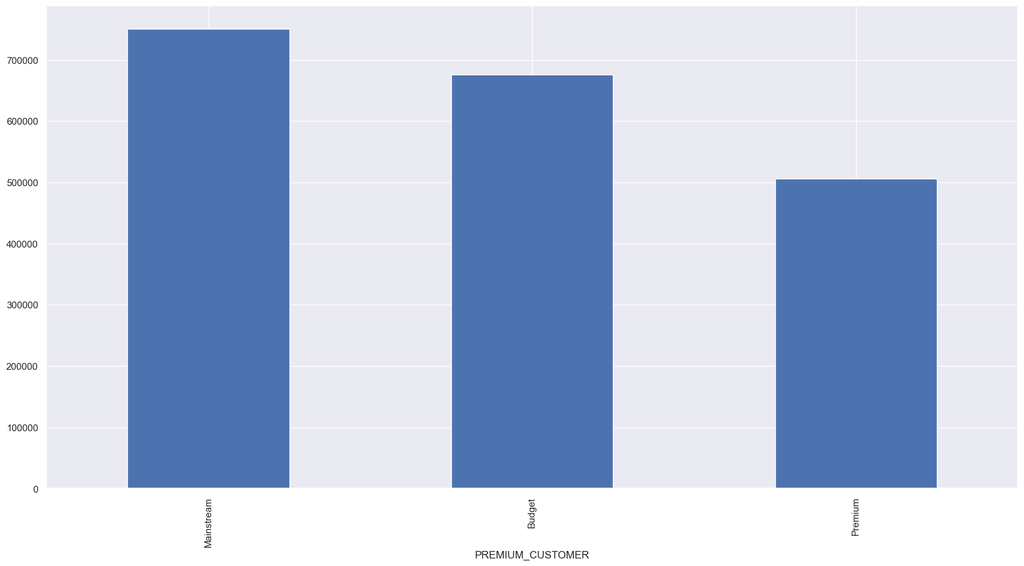

```python
merge_data.groupby("PREMIUM_CUSTOMER")['TOT_SALES'].sum().sort_values(ascending=False).plot(kind= "bar",figsize=(20,10))
```

### Working with LIFESTAGE -----

```python
# Check which of the LIFESTAGE categories are the most purchased----

merge_data.groupby("LIFESTAGE")['TOT_SALES'].sum().sort_values(ascending=False)
```

```
LIFESTAGE
OLDER SINGLES/COUPLES     402426.75
RETIREES                  366470.90
OLDER FAMILIES            352480.20
YOUNG FAMILIES            316160.10
YOUNG SINGLES/COUPLES     260405.30
MIDAGE SINGLES/COUPLES    184751.30
NEW FAMILIES              50433.45
Name: TOT_SALES, dtype: float64
```

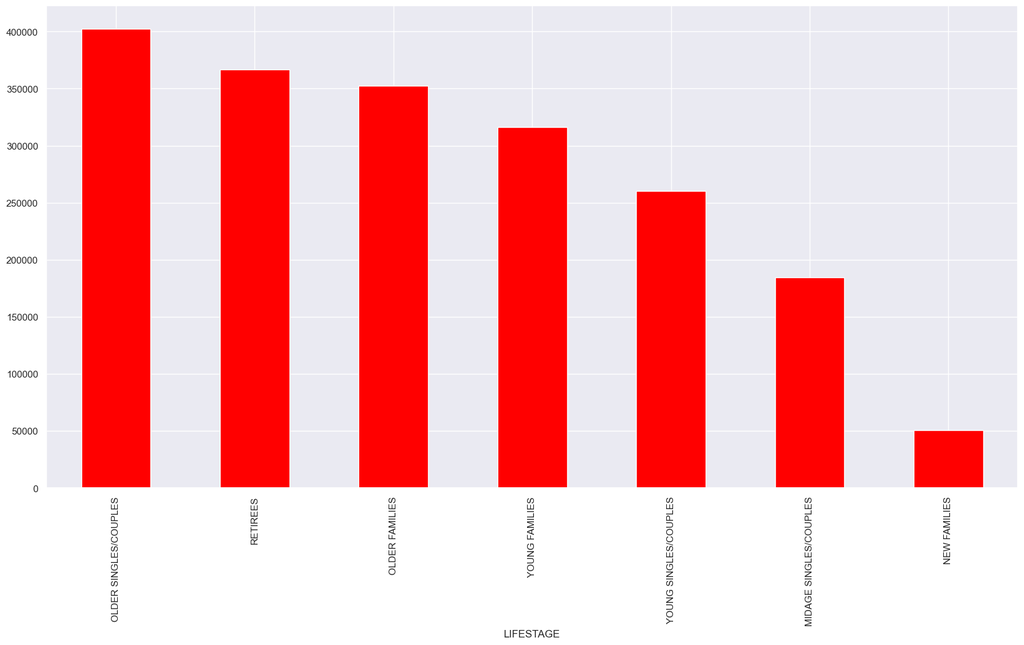

```python
merge_data.groupby("LIFESTAGE")['TOT_SALES'].sum().sort_values(ascending=False).plot(kind= "bar",
                                                                                     color="red",figsize=(20,10))
```

```python
merge_data.pivot_table(index=['LIFESTAGE'], values='TOT_SALES',
                            columns= 'STORE_NBR',
                            aggfunc= np.sum).sort_values(by='LIFESTAGE', ascending=False)
```

| STORE_NBR LIFESTAGE | 1 | 2 | 3 | 4 | 5 | 6 | 7 | 8 | 9 | 10 | 11 | 12 | 13 | 14 | 15 | 16 | 17 | 18 | 19 | 20 | 21 | 22 | 23 | 24 | 25 | 26 | 27 | 28 | 29 | … |
| --- | --- | --- | --- | --- | --- | --- | --- | --- | --- | --- | --- | --- | --- | --- | --- | --- | --- | --- | --- | --- | --- | --- | --- | --- | --- | --- | --- | --- | --- | --- |
| YOUNG SINGLES/COUPLES | 744.6 | 572.5 | 1896.20 | 1502.55 | 836.3 | 673.4 | 1653.0 | 1155.0 | 986.9 | 666.60 | 2.9 | 1043.4 | 784.3 | 78.8 | 1065.70 | 449.2 | 1365.7 | 867.7 | 1636.5 | 798.10 | 1199.3 | 990.3 | 1024.5 | 1219.4 | 1151.20 | 2049.3 | 1102.8 | 1277.10 | 1190.4 | … |
| YOUNG FAMILIES | 205.2 | 201.0 | 1726.30 | 1917.30 | 2178.3 | 273.4 | 1538.3 | 325.4 | 398.1 | 2110.35 | NaN | 396.2 | 2190.2 | 68.4 | 2098.10 | 174.4 | 486.0 | 294.3 | 1138.9 | 200.80 | 637.7 | 329.3 | 2467.9 | 1626.7 | 470.80 | 2244.6 | 526.5 | 1706.10 | 473.8 | … |
| RETIREES | 468.7 | 386.1 | 2798.50 | 3611.70 | 1388.3 | 592.4 | 3145.0 | 1118.1 | 800.7 | 1547.40 | NaN | 1132.5 | 1663.0 | 70.4 | 1777.90 | 324.9 | 1145.5 | 624.0 | 2251.3 | 474.65 | 1075.8 | 692.2 | 1491.4 | 1857.9 | 1240.50 | 2722.6 | 1149.3 | 1729.35 | 910.8 | … |
| OLDER SINGLES/COUPLES | 289.1 | 377.4 | 3023.60 | 3660.80 | 1716.4 | 477.4 | 2838.7 | 994.2 | 779.0 | 2629.70 | 3.8 | 1202.7 | 1903.5 | 47.5 | 1854.80 | 265.2 | 560.1 | 674.0 | 2166.6 | 363.70 | 1055.4 | 764.0 | 2166.2 | 1904.8 | 957.15 | 3096.9 | 770.8 | 1564.90 | 885.7 | … |
| OLDER FAMILIES | 328.2 | 186.5 | 1910.20 | 1747.50 | 2331.0 | 275.7 | 1622.8 | 313.9 | 452.4 | 2240.00 | NaN | 494.3 | 2917.8 | 72.4 | 1807.05 | 146.6 | 437.1 | 274.6 | 825.9 | 201.40 | 535.9 | 443.8 | 1952.3 | 1735.3 | 722.50 | 2065.3 | 544.7 | 2230.10 | 495.9 | … |
| NEW FAMILIES | 145.5 | 93.0 | 404.40 | 642.00 | 142.4 | 117.8 | 352.3 | 118.8 | 193.8 | 110.80 | NaN | 215.4 | 144.2 | 43.8 | 239.10 | 84.7 | 127.8 | 226.0 | 129.7 | 166.20 | 172.2 | 196.0 | 71.0 | 312.6 | 190.20 | 556.2 | 343.2 | 73.70 | 148.7 | … |
| MIDAGE SINGLES/COUPLES | 212.3 | 189.3 | 1043.25 | 1565.80 | 908.1 | 274.8 | 1336.8 | 473.8 | 401.5 | 997.45 | NaN | 525.4 | 1083.5 | 29.4 | 643.40 | 187.1 | 514.4 | 309.1 | 824.0 | 314.40 | 478.6 | 273.8 | 1132.5 | 573.3 | 565.30 | 1734.4 | 683.4 | 793.10 | 592.2 | … |

#### Numbers of transactions per LIFESTAGE -----

```python
merge_data.pivot_table(index=['LIFESTAGE'], values='LYLTY_CARD_NBR',
                                                 margins=True,
                                                aggfunc='count').sort_values(by='LIFESTAGE',ascending=False)
```

| LIFESTAGE | LYLTY_CARD_NBR |
| --- | --- |
| YOUNG SINGLES/COUPLES | 36377 |
| YOUNG FAMILIES | 43592 |
| RETIREES | 49763 |
| OLDER SINGLES/COUPLES | 54479 |
| OLDER FAMILIES | 48596 |
| NEW FAMILIES | 6919 |
| MIDAGE SINGLES/COUPLES | 25110 |
| All | 264836 |

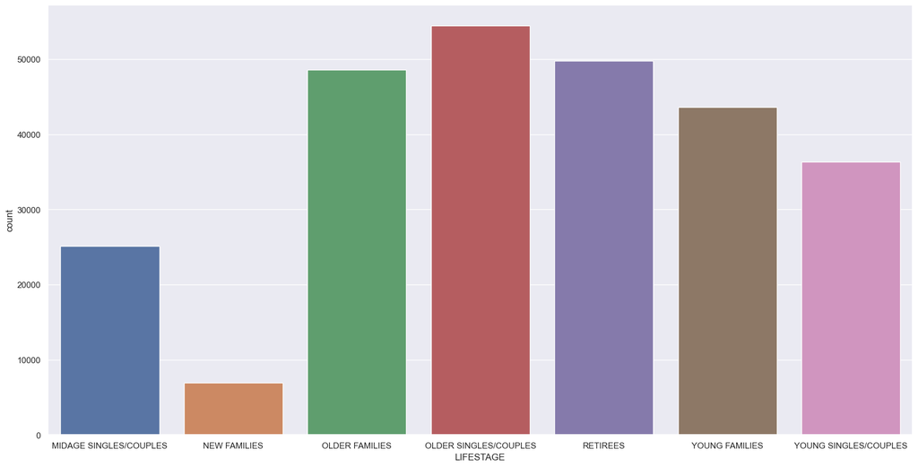

```python
fig_dim = (20, 10)
f, ax = plt.subplots(figsize = fig_dim)
sns.countplot( data=merge_data, x='LIFESTAGE', ax=ax)
```

### Create a new data conatins sotres numbers 77, 86, and 88 ----

```python
stores_77_86_88 = merge_data[(merge_data["STORE_NBR"] == 77 ) |
                      (merge_data["STORE_NBR"] == 86)|
                      (merge_data["STORE_NBR"] == 88)]
```

```python
stores_77_86_88
```

| DATE | STORE_NBR | LYLTY_CARD_NBR | PROD_NAME | PROD_QTY | TOT_SALES | Net_Weight | LIFESTAGE | PREMIUM_CUSTOMER |
| --- | --- | --- | --- | --- | --- | --- | --- | --- |
| 2018-07-01 | 88 | 88076 | Kettle Tortilla ChpsBtroot&Ricotta 150g | 2 | 9.2 | 150g | MIDAGE SINGLES/COUPLES | Mainstream |
| 2019-02-25 | 88 | 88076 | Pringles Slt Vingar 134g | 2 | 7.4 | 134g | MIDAGE SINGLES/COUPLES | Mainstream |
| 2019-03-19 | 88 | 88076 | Pringles SourCream Onion 134g | 2 | 7.4 | 134g | MIDAGE SINGLES/COUPLES | Mainstream |
| 2018-07-01 | 88 | 88140 | Pringles SourCream Onion 134g | 2 | 7.4 | 134g | MIDAGE SINGLES/COUPLES | Mainstream |
| 2019-02-21 | 88 | 88140 | Kettle Chilli 175g | 2 | 10.8 | 175g | MIDAGE SINGLES/COUPLES | Mainstream |
| ... | ... | ... | ... | ... | ... | ... | ... | ... |
| 2019-06-22 | 77 | 77438 | Kettle Sea Salt And Vinegar 175g | 2 | 10.8 | 175g | NEW FAMILIES | Budget |
| 2019-06-22 | 77 | 77235 | Pringles Chicken Salt Crips 134g | 2 | 7.4 | 134g | RETIREES | Budget |
| 2019-06-22 | 77 | 2330081 | Doritos Corn Chips Cheese Supreme 170g | 2 | 8.8 | 170g | RETIREES | Mainstream |
| 2019-06-28 | 77 | 77076 | RRD Sweet Chilli & Sour Cream 165g | 2 | 6.0 | 165g | YOUNG SINGLES/COUPLES | Budget |
| 2019-06-29 | 77 | 2330271 | Kettle Sensations Siracha Lime 150g | 2 | 9.2 | 150g | YOUNG FAMILIES | Mainstream |

3974 rows × 8 columns

```python
stores_77_86_88.info()
```

```
<class 'pandas.core.frame.DataFrame'>
DatetimeIndex: 3974 entries, 2018-07-01 to 2019-06-29
Data columns (total 8 columns):
 #   Column            Non-Null Count  Dtype
---  ------            --------------  -----
 0   STORE_NBR         3974 non-null   int64
 1   LYLTY_CARD_NBR    3974 non-null   int64
 2   PROD_NAME         3974 non-null   object
 3   PROD_QTY          3974 non-null   int64
 4   TOT_SALES         3974 non-null   float64
 5   Net_Weight        3974 non-null   object
 6   LIFESTAGE         3974 non-null   object
 7   PREMIUM_CUSTOMER  3974 non-null   object
dtypes: float64(1), int64(3), object(4)
memory usage: 279.4+ KB
```

```python
stores_77_86_88.reset_index(inplace=True)
```

```python
stores_77_86_88
```

|  | DATE | STORE_NBR | LYLTY_CARD_NBR | PROD_NAME | PROD_QTY | TOT_SALES | Net_Weight | LIFESTAGE | PREMIUM_CUSTOMER |
| --- | --- | --- | --- | --- | --- | --- | --- | --- | --- |
| 0 | 2018-07-01 | 88 | 88076 | Kettle Tortilla ChpsBtroot&Ricotta 150g | 2 | 9.2 | 150g | MIDAGE SINGLES/COUPLES | Mainstream |
| 1 | 2019-02-25 | 88 | 88076 | Pringles Slt Vingar 134g | 2 | 7.4 | 134g | MIDAGE SINGLES/COUPLES | Mainstream |
| 2 | 2019-03-19 | 88 | 88076 | Pringles SourCream Onion 134g | 2 | 7.4 | 134g | MIDAGE SINGLES/COUPLES | Mainstream |
| 3 | 2018-07-01 | 88 | 88140 | Pringles SourCream Onion 134g | 2 | 7.4 | 134g | MIDAGE SINGLES/COUPLES | Mainstream |
| 4 | 2019-02-21 | 88 | 88140 | Kettle Chilli 175g | 2 | 10.8 | 175g | MIDAGE SINGLES/COUPLES | Mainstream |
| ... | ... | ... | ... | ... | ... | ... | ... | ... | ... |
| 3969 | 2019-06-22 | 77 | 77438 | Kettle Sea Salt And Vinegar 175g | 2 | 10.8 | 175g | NEW FAMILIES | Budget |
| 3970 | 2019-06-22 | 77 | 77235 | Pringles Chicken Salt Crips 134g | 2 | 7.4 | 134g | RETIREES | Budget |
| 3971 | 2019-06-22 | 77 | 2330081 | Doritos Corn Chips Cheese Supreme 170g | 2 | 8.8 | 170g | RETIREES | Mainstream |
| 3972 | 2019-06-28 | 77 | 77076 | RRD Sweet Chilli & Sour Cream 165g | 2 | 6.0 | 165g | YOUNG SINGLES/COUPLES | Budget |
| 3973 | 2019-06-29 | 77 | 2330271 | Kettle Sensations Siracha Lime 150g | 2 | 9.2 | 150g | YOUNG FAMILIES | Mainstream |

3974 rows × 9 columns

```python
# Convert Month Number to Full Month Name ----
stores_77_86_88['MONTH'] = stores_77_86_88['DATE'].dt.month_name() #  convert to month name ---
```

```python
stores_77_86_88
```

|  | DATE | STORE_NBR | LYLTY_CARD_NBR | PROD_NAME | PROD_QTY | TOT_SALES | Net_Weight | LIFESTAGE | PREMIUM_CUSTOMER | MONTH |
| --- | --- | --- | --- | --- | --- | --- | --- | --- | --- | --- |
| 0 | 2018-07-01 | 88 | 88076 | Kettle Tortilla ChpsBtroot&Ricotta 150g | 2 | 9.2 | 150g | MIDAGE SINGLES/COUPLES | Mainstream | July |
| 1 | 2019-02-25 | 88 | 88076 | Pringles Slt Vingar 134g | 2 | 7.4 | 134g | MIDAGE SINGLES/COUPLES | Mainstream | February |
| 2 | 2019-03-19 | 88 | 88076 | Pringles SourCream Onion 134g | 2 | 7.4 | 134g | MIDAGE SINGLES/COUPLES | Mainstream | March |
| 3 | 2018-07-01 | 88 | 88140 | Pringles SourCream Onion 134g | 2 | 7.4 | 134g | MIDAGE SINGLES/COUPLES | Mainstream | July |
| 4 | 2019-02-21 | 88 | 88140 | Kettle Chilli 175g | 2 | 10.8 | 175g | MIDAGE SINGLES/COUPLES | Mainstream | February |
| ... | ... | ... | ... | ... | ... | ... | ... | ... | ... | ... |
| 3969 | 2019-06-22 | 77 | 77438 | Kettle Sea Salt And Vinegar 175g | 2 | 10.8 | 175g | NEW FAMILIES | Budget | June |
| 3970 | 2019-06-22 | 77 | 77235 | Pringles Chicken Salt Crips 134g | 2 | 7.4 | 134g | RETIREES | Budget | June |
| 3971 | 2019-06-22 | 77 | 2330081 | Doritos Corn Chips Cheese Supreme 170g | 2 | 8.8 | 170g | RETIREES | Mainstream | June |
| 3972 | 2019-06-28 | 77 | 77076 | RRD Sweet Chilli & Sour Cream 165g | 2 | 6.0 | 165g | YOUNG SINGLES/COUPLES | Budget | June |
| 3973 | 2019-06-29 | 77 | 2330271 | Kettle Sensations Siracha Lime 150g | 2 | 9.2 | 150g | YOUNG FAMILIES | Mainstream | June |

3974 rows × 10 columns

### Total sales for 77,86, and 88 stores per month ----

```python
stores_77_86_88.pivot_table(index=['STORE_NBR'], values='TOT_SALES',
                            columns= 'MONTH',
                            aggfunc= np.sum,
                            margins=True,
                            margins_name='Total').sort_values(by='Total', ascending=False)
```

| MONTH STORE_NBR | April | August | December | February | January | July | June | March | May | November | October | September | Total |
| --- | --- | --- | --- | --- | --- | --- | --- | --- | --- | --- | --- | --- | --- |
| Total | 2551.1 | 2343.35 | 2433.7 | 2518.4 | 2312.2 | 2499.0 | 2457.3 | 2782.5 | 2496.85 | 2546.1 | 2505.3 | 2562.8 | 30008.60 |
| 88 | 1439.4 | 1323.80 | 1325.2 | 1370.2 | 1266.4 | 1310.0 | 1354.6 | 1477.2 | 1308.25 | 1382.8 | 1352.4 | 1423.0 | 16333.25 |
| 86 | 848.2 | 764.05 | 841.2 | 913.2 | 841.4 | 892.2 | 838.0 | 1026.8 | 889.30 | 918.0 | 948.4 | 914.6 | 10635.35 |
| 77 | 263.5 | 255.50 | 267.3 | 235.0 | 204.4 | 296.8 | 264.7 | 278.5 | 299.30 | 245.3 | 204.5 | 225.2 | 3040.00 |

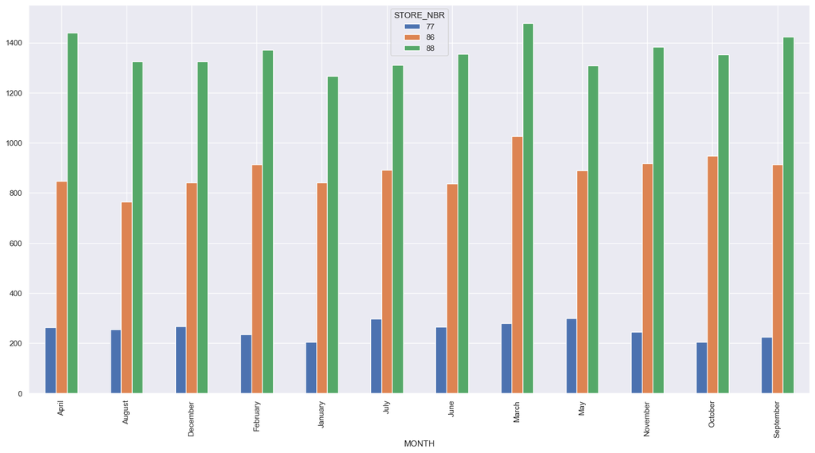

```python
stores_77_86_88.pivot_table(index=['MONTH'], values='TOT_SALES',
                            columns= 'STORE_NBR',
                            aggfunc= np.sum).plot(kind= "bar",figsize=(20,10))
```

### Total sales for 77, 86, and 88 stores per LIFESTAGE ----

```python
stores_77_86_88.pivot_table(index=['LIFESTAGE'], values= 'TOT_SALES',
                           aggfunc=np.sum).sort_values(by='TOT_SALES',
                                        ascending=False)
```

| LIFESTAGE | TOT_SALES |
| --- | --- |
| OLDER SINGLES/COUPLES | 6895.45 |
| OLDER FAMILIES | 6115.90 |
| RETIREES | 5486.80 |
| YOUNG FAMILIES | 4717.05 |
| YOUNG SINGLES/COUPLES | 3193.80 |
| MIDAGE SINGLES/COUPLES | 2876.30 |
| NEW FAMILIES | 723.30 |

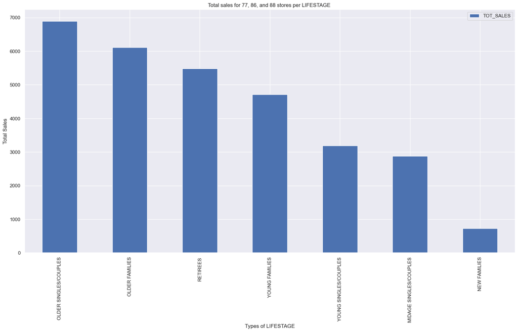

```python
stores_77_86_88.pivot_table(index=['LIFESTAGE'], values= 'TOT_SALES',
                           aggfunc=np.sum).sort_values(by='TOT_SALES',
                                        ascending=False).plot(kind= "bar",figsize=(20,10),
                                                          title='Total sales for 77, 86, and 88 stores per LIFESTAGE ',
                                                            ylabel='Total Sales', xlabel='Types of LIFESTAGE')
```

```python
stores_77_86_88.pivot_table(index=['STORE_NBR'], values='TOT_SALES',
                            columns= 'LIFESTAGE',
                            aggfunc= np.sum,
                            margins=True,
                            margins_name='Total').sort_values(by='Total', ascending=False)
```

| LIFESTAGE STORE_NBR | MIDAGE SINGLES/COUPLES | NEW FAMILIES | OLDER FAMILIES | OLDER SINGLES/COUPLES | RETIREES | YOUNG FAMILIES | YOUNG SINGLES/COUPLES | Total |
| --- | --- | --- | --- | --- | --- | --- | --- | --- |
| Total | 2876.3 | 723.3 | 6115.9 | 6895.45 | 5486.8 | 4717.05 | 3193.8 | 30008.60 |
| 88 | 1800.2 | 223.0 | 3232.8 | 4187.65 | 2993.9 | 2538.30 | 1357.4 | 16333.25 |
| 86 | 871.1 | 354.3 | 2534.9 | 2146.70 | 1778.1 | 1913.35 | 1036.9 | 10635.35 |
| 77 | 205.0 | 146.0 | 348.2 | 561.10 | 714.8 | 265.40 | 799.5 | 3040.00 |

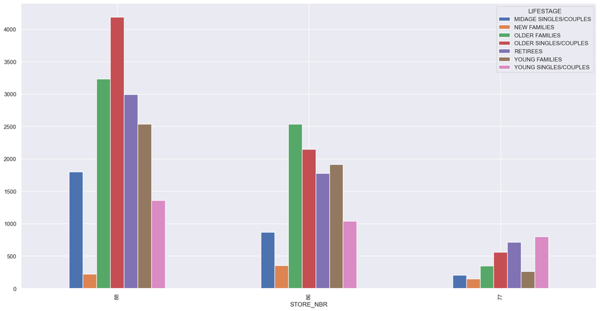

```python
stores_77_86_88.pivot_table(index=['STORE_NBR'], values='TOT_SALES',
                            columns= 'LIFESTAGE',
                            aggfunc= np.sum).sort_values(by='STORE_NBR', ascending=False).plot(kind= "bar",figsize=(20,10))
```

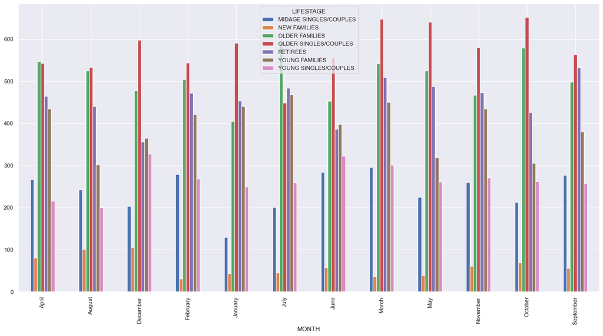

```python
stores_77_86_88.pivot_table(index=['MONTH'], values='TOT_SALES',
                            columns= 'LIFESTAGE',
                            aggfunc= np.sum).plot(kind= "bar",figsize=(20,10))
```

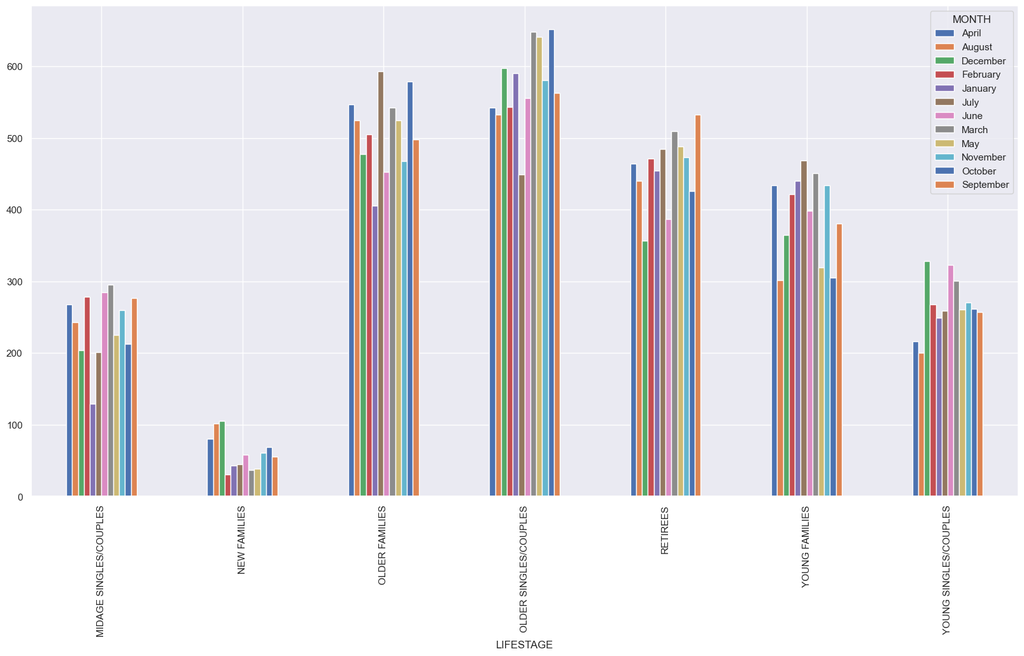

```python
stores_77_86_88.pivot_table(index=["LIFESTAGE"], values='TOT_SALES',
                            columns= 'MONTH',
                            aggfunc= np.sum).plot(kind= "bar",figsize=(20,10))
```